# forecast

Executing Summary:

We have negative prices but we were told it is fine. The high prices in Jan 2021 are explained in https://auroraer.com/insight/gb-wholesale-market-summary-january-2021/

We have created the following features. For the previous values of "forecast_wind_mw", "national_demand_mw", "embedded_solar_generation_mw" and "price_gbp" given hour we computed statistics "median", "std", "Q25", "Q75", "max" and "ORDER" (order define the lag). We also use features such as season (winter, spring, summer and autumn) and hour (0-23).

We use the following time interval for train, validation and test datasets:  
1) train, 2019-07-10 00:00:00 - 2020-09-17 18:00:00;  
2) validation, 2020-09-17 19:00:00 2021-02-07 08:00:00;  
3) test, 2021-02-07 09:00:0 2021-06-29 23:00:00.

It seems GP SW perform better than GP ALL but we have not optimise it performance using different features, kernels and etc.

The Prophet procedure is an additive regression model with four main components — a piecewise linear logistic growth curve trend; a yearly seasonal component modelled using Fourier series; a weekly seasonal component created using dummy variables; a user-provided list of important holidays. We did not use Bank holidays in our model but it is really easy to update the model with this functionality.

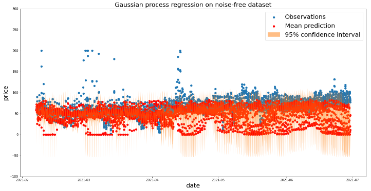

Fig. 1 Illustration of performance for GP ALL using test dataset.

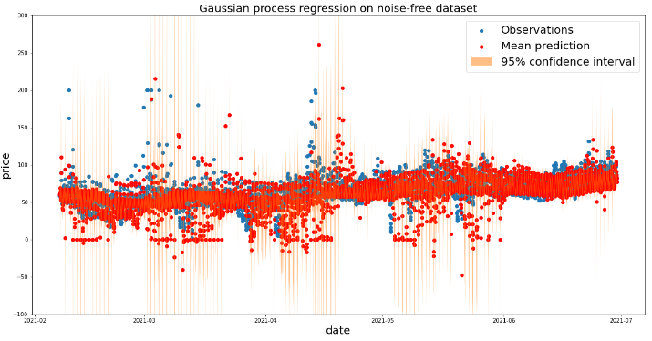

Fig. 2 Illustration of performance for GP SW using test dataset.

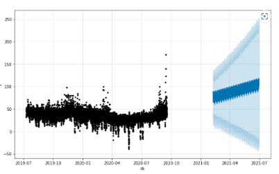

Fig. 3 Illustration of forecast by FP N1 model, black dots are training dataset and blue ones are test dataset prediction.

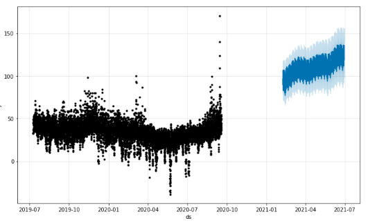

Fig. 4 Illustration of forecast by FP N2 model, black dots are training dataset and blue ones are test dataset prediction.

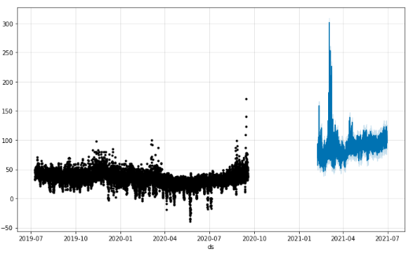

Fig. 5 Illustration of forecast by FP N3 model, black dots are training dataset and blue ones are test dataset prediction.

Table 2 Performance of Facebook Prophet

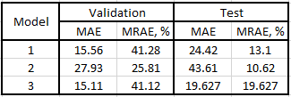

### Future work:

At the moment I training dataset fixed but we can use it in sliding window fashion - we will use all data that are availble before making the prediction to train the model.

We can use the forecast of "national_demand_mw" and "embedded_solar_generation_mw" as features obtained by other models. Hyperparameters Facebook Prophet can be selected using validation dataset.

We can use transformer for forecast: https://towardsdatascience.com/how-to-make-a-pytorch-transformer-for-time-series-forecasting-69e073d4061e  
or Bayesian LSTM https://colab.research.google.com/github/PawaritL/BayesianLSTM/blob/master/Energy_Consumption_Predictions_with_Bayesian_LSTMs_in_PyTorch.ipynb#scrollTo=3FQQioKQ-Tkr

```python
import pandas as pd
import numpy as np
import seaborn as sns
import matplotlib.pyplot as plt
from matplotlib import pyplot
from statsmodels.graphics.tsaplots import plot_acf, plot_pacf
from prophet import Prophet
```

```python
import os
from time import time
import warnings
warnings.filterwarnings("ignore")
#
from sklearn.gaussian_process import GaussianProcessRegressor
from sklearn.gaussian_process.kernels import RBF, WhiteKernel
```

```python
# Plot distribution of features for every group or class defined by variable "groupby" (see below)
# slices_values are feature under consideretion
def compare_variables(df, slice_values, groupby='y', title = "", order = []):

    for gl in slice_values:
        fig, ax = plt.subplots(1,2,figsize=[15,5])
        if len(order) > 0:
           sns.violinplot(x=groupby, y=gl, data=df, order = order, height = 5, aspect = 1.7, ax = ax[0]).set_title(title)
        else:
           sns.violinplot(x=groupby, y=gl, data=df,                height = 5, aspect = 1.7, ax = ax[0]).set_title(title)
        #
        groups = df.groupby(groupby)
        for t in df[groupby].unique():
            dftmp = groups.get_group(t)
            try:
               sns.kdeplot(dftmp[gl], ax = ax[1], shade = True, label = t).set_title(title)
            except Exception as e:
               print("Exception: ", str(e))
        #
        ax[1].set_xlabel(gl)
        ax[1].legend(title = groupby)
        #ax[1].set_xlim(xlim[0], xlim[1])
        ax[0].grid()
    plt.show()
    return plt
```

```python
#Perform Dickey-Fuller test:
# H0: The time series is non-stationary.
# In other words, it has some time-dependent structure and does not have constant variance over time.
# HA: The time series is stationary.
#
# plot rolling mean and std.
from statsmodels.tsa.stattools import adfuller
def test_stationarity(df, difference = "Y", col = "price_gbp", window = 11, center = True):
    if difference == "N":
       timeseries = df[col]
    else:
       timeseries = df
    #
    #Determing rolling statistics
    rolmean = timeseries.rolling(window = window, center = center).apply(lambda x: np.mean(x))
    rolstd  = timeseries.rolling(window = window, center = center).apply(lambda x: np.std(x))
    #
    #Plot rolling statistics:
    fig = plt.figure(figsize=(12, 8))
    if difference == "N":
       orig = plt.plot(df["Date"], timeseries, color = 'blue',  label = 'Original')
       mean = plt.plot(df["Date"], rolmean,    color = 'red',   label = 'Rolling Mean')
       std  = plt.plot(df["Date"], rolstd,     color = 'black', label = 'Rolling Std')
    else:
       orig = plt.plot(timeseries, color = 'blue',  label = 'Original')
       mean = plt.plot(rolmean,    color = 'red',   label = 'Rolling Mean')
       std  = plt.plot(rolstd,     color = 'black', label = 'Rolling Std')
    #
    plt.legend(loc='best')
    plt.title('Rolling Mean & Standard Deviation')
    plt.show()

    print('Results of Dickey-Fuller Test:')
    dftest = adfuller(timeseries, autolag='AIC')
    dfoutput = pd.Series(dftest[0:4], index=['Test Statistic','p-value','#Lags Used','Number of Observations Used'])
    for key,value in dftest[4].items():
        dfoutput['Critical Value (%s)'%key] = value
    print(dfoutput)
```

```python
# remove outliers
dd = pd.DataFrame({"n": range(21)})
def remove_large_value(df):
    Q1 = df.quantile(0.25)
    Q3 = df.quantile(0.75)
    IQR = Q3 - Q1
    #
    last = df.values[-1]
    #
    if (last < (Q1 - 1.5 * IQR)) | (last > (Q3 + 1.5 * IQR)):
       last = np.median(df.values)
    #
    return last
# test how it works
dd["last"] = dd["n"].rolling(window=5, center=False).apply(lambda x: remove_large_value(x))
dd
```

|  | n | last |
| --- | --- | --- |
| 0 | 0 | NaN |
| 1 | 1 | NaN |
| 2 | 2 | NaN |
| 3 | 3 | NaN |
| 4 | 4 | 4.0 |
| 5 | 5 | 5.0 |
| 6 | 6 | 6.0 |
| 7 | 7 | 7.0 |
| 8 | 8 | 8.0 |
| 9 | 9 | 9.0 |
| 10 | 10 | 10.0 |
| 11 | 11 | 11.0 |
| 12 | 12 | 12.0 |
| 13 | 13 | 13.0 |
| 14 | 14 | 14.0 |
| 15 | 15 | 15.0 |
| 16 | 16 | 16.0 |
| 17 | 17 | 17.0 |
| 18 | 18 | 18.0 |
| 19 | 19 | 19.0 |
| 20 | 20 | 20.0 |

```python
# 0 - Winter, 1 Spring etc.
def get_season(x):
    if   x in [12, 1, 2]:
         season = 0
    elif x in [3, 4, 5]:
         season = 1
    elif x in [6, 7, 8]:
         season = 2
    elif x in [9, 10, 11]:
         season = 3
    return season
```

```python
# We compute Mean Absolute Error and Mean Relative Absolute Error, %.
def preformance(m, data):
    fcst = m.predict(data)
    pred = fcst.merge(data[["ds", "y"]], on = "ds")
    #
    pred["MAE" ] = pred.apply(lambda x: np.abs(x["yhat"] -x["y"]), axis = 1)
    pred["MRAE"] = pred["yhat"] - pred["y"] * 100 / pred["y"]
    pred["MRAE"] = pred["MRAE"].apply(lambda x: np.abs(x))
    #
    MAE  = pred["MAE" ].mean()
    MRAE = pred["MRAE"].mean()
    #
    return MAE, MRAE
```

```python
def replace_missing_values(x, values = [-999999, 999999]):
    dd = x.values[::24]
    #print("dd: ", dd)
    last_value = x.values[-1]
    #
    if last_value in values:
       value = np.nanmedian(dd)
    else:
       value = dd[-1]
    #
    return value
```

```python
df = pd.read_csv("data.csv")
df.describe()
```

|  | forecast_wind_mw | national_demand_mw | embedded_solar_generation_mw | price_gbp |
| --- | --- | --- | --- | --- |
| count | 17472.000000 | 17568.000000 | 17568.000000 | 17568.000000 |
| mean | 5733.860062 | 28097.403575 | 1346.136100 | 44.363583 |
| std | 13562.854070 | 14508.180308 | 2092.550166 | 29.551848 |
| min | -999999.000000 | -999999.000000 | 0.000000 | -38.800000 |
| 25% | 2555.000000 | 22947.000000 | 0.000000 | 30.900000 |
| 50% | 5022.500000 | 27262.000000 | 10.000000 | 40.000000 |
| 75% | 8411.500000 | 32445.250000 | 2170.000000 | 53.760000 |
| max | 999999.000000 | 999999.000000 | 9680.000000 | 1500.000000 |

# Explonatory Analysis

We check missing values, outliers and relationship between prices and other features.

```python
dataset =  df.copy()
#
Datetime = "settlement_period"
#
dataset["ds"    ] = pd.to_datetime(df[Datetime])
dataset["Month" ] = pd.to_datetime(df[Datetime]).dt.month
dataset["Year"  ] = pd.to_datetime(df[Datetime]).dt.year
dataset["Date"  ] = pd.to_datetime(df[Datetime]).dt.date
dataset["Hour"  ] = pd.to_datetime(df[Datetime]).dt.hour
dataset["Week"  ] = pd.to_datetime(df[Datetime]).dt.week
dataset["Day"   ] = pd.to_datetime(df[Datetime]).dt.day_name()
dataset["season"] = dataset["Month"].apply(lambda x: get_season(x))
#
dataset.head()
```

|  | settlement_period | forecast_wind_mw | national_demand_mw | embedded_solar_generation_mw | price_gbp | ds | Month | Year | Date | Hour | Week | Day | season |
| --- | --- | --- | --- | --- | --- | --- | --- | --- | --- | --- | --- | --- | --- |
| 0 | 2019-07-01 00:00:00 | 7939.0 | 18248 | 0 | 21.75 | 2019-07-01 00:00:00 | 7 | 2019 | 2019-07-01 | 0 | 27 | Monday | 2 |
| 1 | 2019-07-01 01:00:00 | 8130.0 | 17687 | 0 | 19.65 | 2019-07-01 01:00:00 | 7 | 2019 | 2019-07-01 | 1 | 27 | Monday | 2 |
| 2 | 2019-07-01 02:00:00 | 8238.0 | 17143 | 0 | 17.99 | 2019-07-01 02:00:00 | 7 | 2019 | 2019-07-01 | 2 | 27 | Monday | 2 |
| 3 | 2019-07-01 03:00:00 | 8365.0 | 17087 | 0 | 14.92 | 2019-07-01 03:00:00 | 7 | 2019 | 2019-07-01 | 3 | 27 | Monday | 2 |
| 4 | 2019-07-01 04:00:00 | 8497.0 | 17140 | 52 | 21.84 | 2019-07-01 04:00:00 | 7 | 2019 | 2019-07-01 | 4 | 27 | Monday | 2 |

```python
# Count total NaN at each column in DataFrame, forecast_wind_mw has 96 missing values
print(" \nCount total NaN at each column in a DataFrame : \n\n",
      dataset.isnull().sum())
```

```
Count total NaN at each column in a DataFrame :

 settlement_period                0
forecast_wind_mw                96
national_demand_mw               0
embedded_solar_generation_mw     0
price_gbp                        0
ds                               0
Month                            0
Year                             0
Date                             0
Hour                             0
Week                             0
Day                              0
season                           0
dtype: int64
```

```python
# remove missing values and outliers in forecast_wind_mw and national_demand_mw
window = 24 * 4 + 1 #
# replace missing values by median
dataset["forecast_wind_mw"] = dataset["forecast_wind_mw"].fillna(-999999)
dataset["forecast_wind_mw"] = dataset["forecast_wind_mw"].rolling(window = window, center=False).apply(lambda x: replace_missing_values(x))
#
# remove extreme values: -999999 and 999999
dataset["national_demand_mw"] = dataset["national_demand_mw"].rolling(window = window, center=False).apply(lambda x: replace_missing_values(x))
#
dataset = dataset[dataset["forecast_wind_mw"] != -999999].copy()
dataset = dataset.dropna()
dataset.describe()
#
```

|  | forecast_wind_mw | national_demand_mw | embedded_solar_generation_mw | price_gbp | Month | Year | Hour | Week | season |
| --- | --- | --- | --- | --- | --- | --- | --- | --- | --- |
| count | 17472.000000 | 17472.000000 | 17472.000000 | 17472.000000 | 17472.000000 | 17472.000000 | 17472.000000 | 17472.000000 | 17472.000000 |
| mean | 5695.030907 | 28056.603136 | 1338.970524 | 44.398505 | 6.509615 | 2020.001374 | 11.500000 | 26.723901 | 1.497253 |
| std | 3591.717288 | 6550.370433 | 2085.765719 | 29.623345 | 3.462601 | 0.704206 | 6.922385 | 15.253139 | 1.118063 |
| min | 378.000000 | 13367.000000 | 0.000000 | -38.800000 | 1.000000 | 2019.000000 | 0.000000 | 1.000000 | 0.000000 |
| 25% | 2563.000000 | 22947.000000 | 0.000000 | 30.857500 | 3.750000 | 2020.000000 | 5.750000 | 13.000000 | 0.750000 |
| 50% | 5051.000000 | 27259.000000 | 9.000000 | 40.000000 | 6.500000 | 2020.000000 | 11.500000 | 27.000000 | 1.000000 |
| 75% | 8443.000000 | 32466.750000 | 2140.000000 | 53.910000 | 10.000000 | 2020.000000 | 17.250000 | 40.000000 | 2.250000 |
| max | 14138.000000 | 46433.000000 | 9680.000000 | 1500.000000 | 12.000000 | 2021.000000 | 23.000000 | 53.000000 | 3.000000 |

```python
# Count total NaN at each column in a DataFrame
print(" \nCount total NaN at each column in a DataFrame : \n\n",
      dataset.isnull().sum())
```

```
Count total NaN at each column in a DataFrame :

 settlement_period               0
forecast_wind_mw                0
national_demand_mw              0
embedded_solar_generation_mw    0
price_gbp                       0
ds                              0
Month                           0
Year                            0
Date                            0
Hour                            0
Week                            0
Day                             0
season                          0
dtype: int64
```

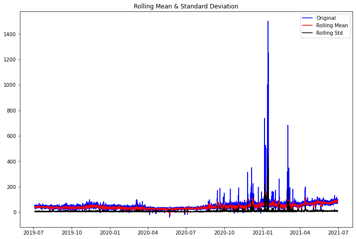

```
Results of Dickey-Fuller Test:
Test Statistic                -6.829237e+00
p-value                        1.912501e-09
#Lags Used                     3.200000e+01
Number of Observations Used    1.743900e+04
Critical Value (1%)           -3.430725e+00
Critical Value (5%)           -2.861706e+00
Critical Value (10%)          -2.566858e+00
dtype: float64
```

```python
# although we have large spikes of prices Dickey-Fuller Test tells that original data are stationary
test_stationarity(dataset, difference = "N")
```

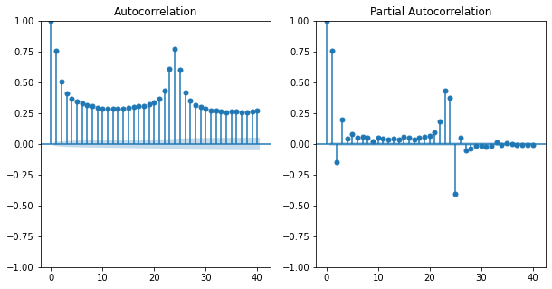

```python
# We can cleary see that the prices kind of have similar patter every 24 hours.
# Autocorrelation has the second peak at around 24.
import statsmodels.api as sm
series = dataset["price_gbp"]
fig, ax = plt.subplots(1,2,figsize=(10,5))
plot_acf( dataset["price_gbp" ].values.squeeze(), lags=40, ax=ax[0])
plot_pacf(dataset["price_gbp" ].values.squeeze(), lags=40, ax=ax[1])
plt.show()
```

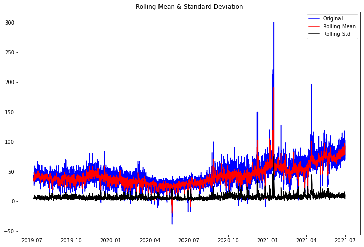

```
Results of Dickey-Fuller Test:
Test Statistic                    -4.222576
p-value                            0.000603
#Lags Used                        44.000000
Number of Observations Used    17411.000000
Critical Value (1%)               -3.430726
Critical Value (5%)               -2.861706
Critical Value (10%)              -2.566858
dtype: float64
```

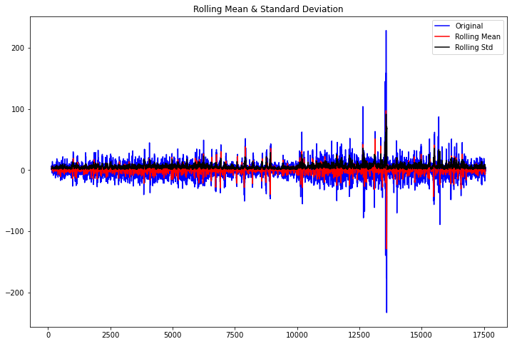

```
Results of Dickey-Fuller Test:
Test Statistic                   -22.728874
p-value                            0.000000
#Lags Used                        44.000000
Number of Observations Used    17387.000000
Critical Value (1%)               -3.430726
Critical Value (5%)               -2.861706
Critical Value (10%)              -2.566858
dtype: float64
```

```python
# we have outliers in prices
# We find difference between prices that are 24 hours apart.
dataset["processed_price_gbp"] = dataset["price_gbp"].rolling(window=17, center=False).apply(lambda x: remove_large_value(x))
#
dataset_drop_na = dataset.dropna()
test_stationarity(dataset_drop_na, difference = "N", col = "processed_price_gbp")
#
remove_season_series = dataset_drop_na
remove_season_series_diff = remove_season_series["processed_price_gbp"] - remove_season_series["processed_price_gbp"].shift(24)
remove_season_series_diff = remove_season_series_diff.dropna()
test_stationarity(remove_season_series_diff)
```

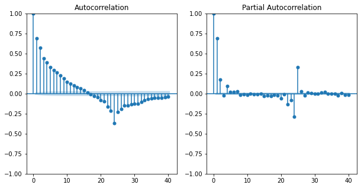

```python
# if we model data using ARMA model then Partial Autocorrlation defined the order of AR and Autocorrelation of MA componenet of ARMA.
# It seems we can model using AR(3).
fig, ax = plt.subplots(1,2,figsize=(10,5))
plot_acf( remove_season_series_diff.values.squeeze(), lags=40, ax=ax[0])
plot_pacf(remove_season_series_diff.values.squeeze(), lags=40, ax=ax[1])
plt.show()
```

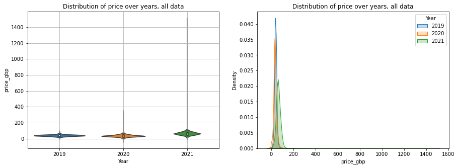

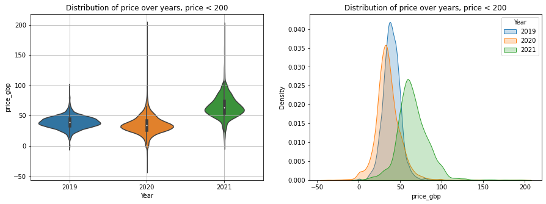

```
<module 'matplotlib.pyplot' from 'C:\\Users\\Alex\\anaconda3\\lib\\site-packages\\matplotlib\\pyplot.py'>
```

```python
# It seems we have slightly higher prices in 2021 compared with other years
years = [2019, 2020, 2021]
#
compare_variables(dataset, ["price_gbp"], groupby = "Year", title = "Distribution of price over years, all data", order = years)
reduced_dataset = dataset[dataset["price_gbp"] < 200].copy()
compare_variables(reduced_dataset, ["price_gbp"], groupby = "Year", title = "Distribution of price over years, price < 200", order = years)
```

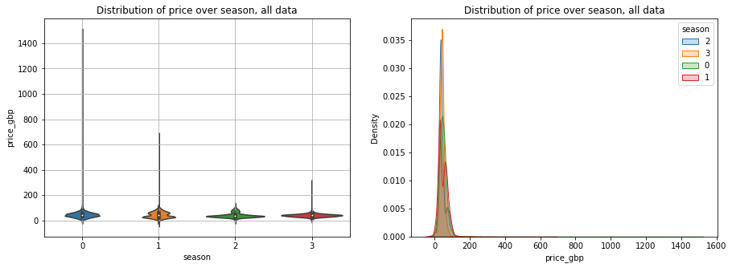

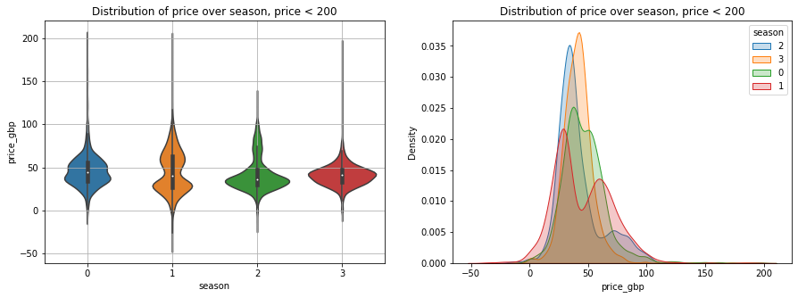

```
<module 'matplotlib.pyplot' from 'C:\\Users\\Alex\\anaconda3\\lib\\site-packages\\matplotlib\\pyplot.py'>
```

```python
#
seasons = [0, 1, 2, 3]
#
compare_variables(dataset, ["price_gbp"], groupby = "season", title = "Distribution of price over season, all data", order = seasons)
reduced_dataset = dataset[dataset["price_gbp"] < 200].copy()
compare_variables(reduced_dataset, ["price_gbp"], groupby = "season", title = "Distribution of price over season, price < 200", order = seasons)
```

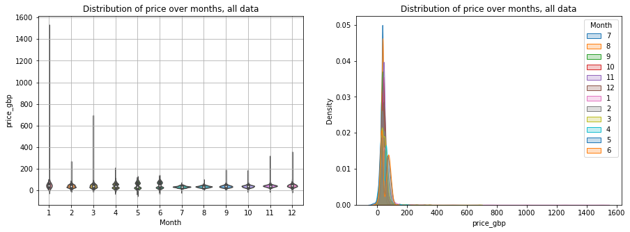

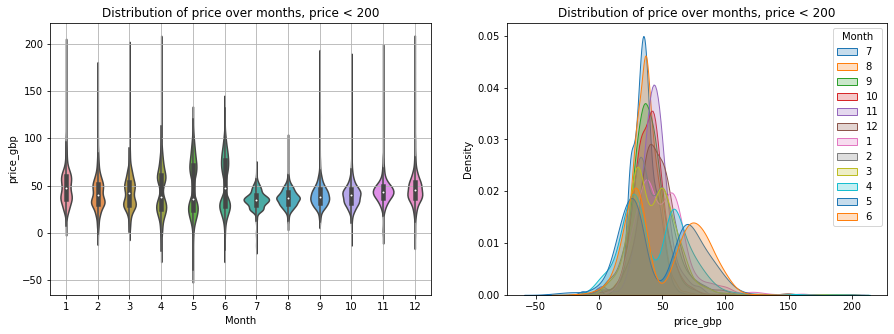

```
<module 'matplotlib.pyplot' from 'C:\\Users\\Alex\\anaconda3\\lib\\site-packages\\matplotlib\\pyplot.py'>
```

```python
#
months = list(range(1, 12 + 1))
#
compare_variables(dataset, ["price_gbp"], groupby = "Month", title = "Distribution of price over months, all data", order = months)
reduced_dataset = dataset[dataset["price_gbp"] < 200].copy()
compare_variables(reduced_dataset, ["price_gbp"], groupby = "Month", title = "Distribution of price over months, price < 200", order = months)
```

```python
# We have bimodal distribution for prices over months
# It is because we have upper shift in median prices in 2021
#
# the hist price in Jan 2021 it is explain in https://auroraer.com/insight/gb-wholesale-market-summary-january-2021/
# Due to colder temperatures, low renewable output levels and limited generator availability, January saw several periods
# of tight system margins. This resulted in National Grid ESO issuing both Capacity Market Notices (CMN) and
# Electricity Margin Notices (EMN) and turning to higher marginal cost generators. Consequently, these periods saw
# wholesale prices in excess of £500/MWh
dataset.groupby(["Month", "Year"])["price_gbp"].describe()
```

| Month | Year | count | mean | std | min | 25% | 50% | 75% | max |
| --- | --- | --- | --- | --- | --- | --- | --- | --- | --- |
| 1 | 2020 | 768.0 | 35.914635 | 9.251804 | 7.25 | 29.9775 | 36.175 | 41.1300 | 65.00 |
|  | 2021 | 744.0 | 79.135067 | 98.082772 | 33.00 | 55.0000 | 61.000 | 70.0000 | 1500.00 |
| 2 | 2020 | 696.0 | 30.628764 | 10.442902 | -4.33 | 25.2500 | 32.000 | 36.7850 | 59.62 |
|  | 2021 | 672.0 | 53.813780 | 17.755366 | 16.50 | 45.6625 | 52.125 | 60.4250 | 262.50 |
| 3 | 2020 | 744.0 | 31.693427 | 11.337918 | 1.43 | 26.4975 | 30.940 | 36.5250 | 99.90 |
|  | 2021 | 744.0 | 56.840874 | 33.986442 | 1.90 | 47.0000 | 53.000 | 62.0000 | 683.00 |
| 4 | 2020 | 720.0 | 24.178708 | 10.151824 | -19.00 | 19.5750 | 26.000 | 31.0425 | 43.41 |
|  | 2021 | 720.0 | 64.882056 | 18.946999 | 5.00 | 56.2750 | 61.200 | 72.0000 | 200.00 |
| 5 | 2020 | 744.0 | 22.142043 | 11.513904 | -38.80 | 17.7550 | 24.670 | 29.9900 | 43.22 |
|  | 2021 | 744.0 | 73.807473 | 15.381450 | 10.00 | 65.0000 | 72.150 | 83.9550 | 120.00 |
| 6 | 2020 | 720.0 | 26.519264 | 8.581261 | -17.65 | 22.7300 | 28.395 | 32.3500 | 42.00 |
|  | 2021 | 720.0 | 77.897681 | 12.492269 | 52.00 | 69.0000 | 76.600 | 85.9250 | 132.00 |
| 7 | 2019 | 648.0 | 41.536821 | 7.544703 | 20.92 | 36.0000 | 40.450 | 46.8850 | 71.00 |
|  | 2020 | 744.0 | 29.451505 | 8.649075 | -16.89 | 25.2600 | 30.495 | 35.0075 | 48.99 |
| 8 | 2019 | 744.0 | 38.127446 | 8.970030 | 10.40 | 32.2375 | 38.030 | 44.7525 | 61.00 |
|  | 2020 | 744.0 | 36.288333 | 10.654193 | 7.63 | 29.3000 | 35.425 | 40.1075 | 99.40 |
| 9 | 2019 | 720.0 | 36.198056 | 9.612462 | 11.94 | 29.3400 | 36.000 | 42.9000 | 70.00 |
|  | 2020 | 720.0 | 43.778153 | 14.997972 | 11.30 | 34.8375 | 41.680 | 49.9850 | 187.10 |
| 10 | 2019 | 744.0 | 36.884355 | 9.238440 | 11.06 | 30.7400 | 35.865 | 43.5975 | 71.50 |
|  | 2020 | 744.0 | 43.385282 | 15.738774 | -7.18 | 35.9100 | 42.880 | 50.0825 | 183.20 |
| 11 | 2019 | 720.0 | 44.457097 | 10.418422 | 16.85 | 37.4925 | 44.000 | 49.9250 | 98.40 |
|  | 2020 | 720.0 | 44.040389 | 20.457520 | -4.36 | 36.7900 | 43.085 | 49.9150 | 313.45 |
| 12 | 2019 | 744.0 | 39.094247 | 11.528190 | -2.84 | 33.9875 | 39.330 | 45.1500 | 84.40 |
|  | 2020 | 744.0 | 55.014046 | 24.417865 | -8.28 | 44.0075 | 52.180 | 60.8500 | 350.00 |

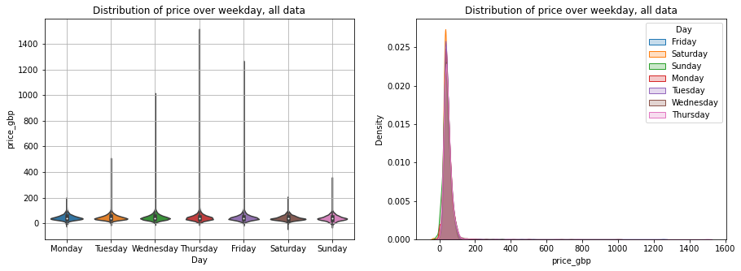

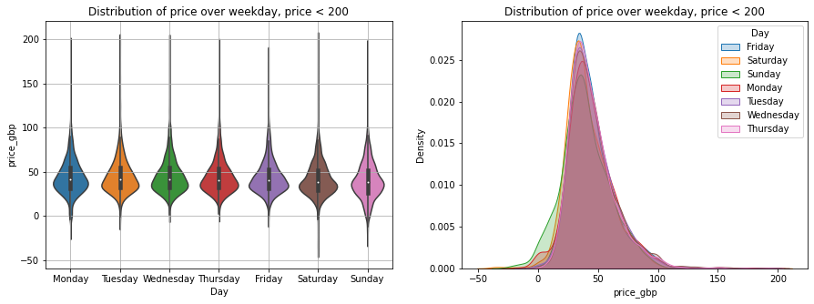

```
<module 'matplotlib.pyplot' from 'C:\\Users\\Alex\\anaconda3\\lib\\site-packages\\matplotlib\\pyplot.py'>
```

```python
#  It seem there is no obvious difference for the prices over week day
weekdays = ['Monday', 'Tuesday', 'Wednesday', 'Thursday', 'Friday', 'Saturday', 'Sunday']
#
compare_variables(dataset, ["price_gbp"], groupby = "Day", title = "Distribution of price over weekday, all data", order = weekdays)
reduced_dataset = dataset[dataset["price_gbp"] < 200].copy()
compare_variables(reduced_dataset, ["price_gbp"], groupby = "Day", title = "Distribution of price over weekday, price < 200", order = weekdays)
```

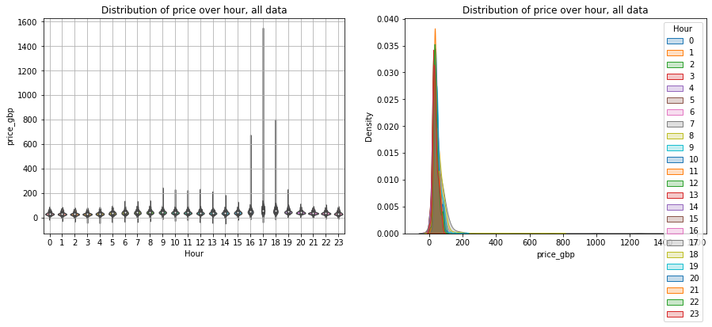

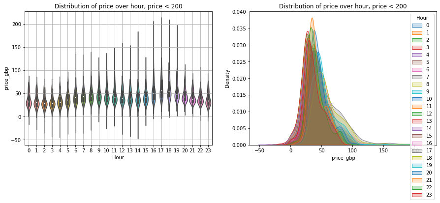

```
<module 'matplotlib.pyplot' from 'C:\\Users\\Alex\\anaconda3\\lib\\site-packages\\matplotlib\\pyplot.py'>
```

```python
# prices really depends on the hour
hours = list(range(24))
#
compare_variables(dataset, ["price_gbp"], groupby = "Hour", title = "Distribution of price over hour, all data", order = hours)
reduced_dataset = dataset[dataset["price_gbp"] < 200].copy()
compare_variables(reduced_dataset, ["price_gbp"], groupby = "Hour", title = "Distribution of price over hour, price < 200", order = hours)
```

# Create training dataset

### I assume that "forecast_wind_mw" has the corresponding date that was forecast for. For example if we have timestampe "01/07/2019 17:00:00" then it means that the value of "forecast_wind_mw" in the corresponding row is forecast for this date and time. Therefore, if we want to use it in our model we need to shift backward by 1 DAY (reduce date by 1 day) and merge with other information that is available on the previous day to the forecast. We do the same for the price_gbp.

```python
copy_dataset = dataset.copy()
del copy_dataset["forecast_wind_mw"],
copy_dataset.rename(columns = {"price_gbp": "previous_price_gbp"}, inplace = True)
copy_dataset["n"] = range(len(copy_dataset))
#
forecast_wind_mw = dataset.shift(-24)[["settlement_period", "forecast_wind_mw", "price_gbp"]].copy()
forecast_wind_mw["n"] = range(len(forecast_wind_mw))
del forecast_wind_mw["settlement_period"]
#
forecast_wind_mw = forecast_wind_mw.merge(copy_dataset, on = "n")
#
forecast_wind_mw.head(25)
```

|  | forecast_wind_mw | price_gbp | n | settlement_period | national_demand_mw | embedded_solar_generation_mw | previous_price_gbp | ds | Month | Year | Date | Hour | Week | Day | season | processed_price_gbp |
| --- | --- | --- | --- | --- | --- | --- | --- | --- | --- | --- | --- | --- | --- | --- | --- | --- |
| 0 | 4282.0 | 34.01 | 0 | 2019-07-05 00:00:00 | 20988.0 | 0 | 32.71 | 2019-07-05 00:00:00 | 7 | 2019 | 2019-07-05 | 0 | 27 | Friday | 2 | NaN |
| 1 | 4275.0 | 30.47 | 1 | 2019-07-05 01:00:00 | 20353.0 | 0 | 31.96 | 2019-07-05 01:00:00 | 7 | 2019 | 2019-07-05 | 1 | 27 | Friday | 2 | NaN |
| 2 | 4306.0 | 30.01 | 2 | 2019-07-05 02:00:00 | 19811.0 | 0 | 31.93 | 2019-07-05 02:00:00 | 7 | 2019 | 2019-07-05 | 2 | 27 | Friday | 2 | NaN |
| 3 | 4294.0 | 27.70 | 3 | 2019-07-05 03:00:00 | 19722.0 | 0 | 31.93 | 2019-07-05 03:00:00 | 7 | 2019 | 2019-07-05 | 3 | 27 | Friday | 2 | NaN |
| 4 | 4064.0 | 27.00 | 4 | 2019-07-05 04:00:00 | 20003.0 | 26 | 32.00 | 2019-07-05 04:00:00 | 7 | 2019 | 2019-07-05 | 4 | 27 | Friday | 2 | NaN |
| 5 | 3793.0 | 30.00 | 5 | 2019-07-05 05:00:00 | 23243.0 | 552 | 39.65 | 2019-07-05 05:00:00 | 7 | 2019 | 2019-07-05 | 5 | 27 | Friday | 2 | NaN |
| 6 | 3517.0 | 32.15 | 6 | 2019-07-05 06:00:00 | 27773.0 | 1640 | 46.07 | 2019-07-05 06:00:00 | 7 | 2019 | 2019-07-05 | 6 | 27 | Friday | 2 | NaN |
| 7 | 3146.0 | 34.00 | 7 | 2019-07-05 07:00:00 | 28395.0 | 3050 | 56.95 | 2019-07-05 07:00:00 | 7 | 2019 | 2019-07-05 | 7 | 27 | Friday | 2 | NaN |
| 8 | 2722.0 | 38.20 | 8 | 2019-07-05 08:00:00 | 28238.0 | 4540 | 53.00 | 2019-07-05 08:00:00 | 7 | 2019 | 2019-07-05 | 8 | 27 | Friday | 2 | NaN |
| 9 | 2366.0 | 40.08 | 9 | 2019-07-05 09:00:00 | 27438.0 | 5900 | 45.59 | 2019-07-05 09:00:00 | 7 | 2019 | 2019-07-05 | 9 | 27 | Friday | 2 | NaN |
| 10 | 2029.0 | 46.00 | 10 | 2019-07-05 10:00:00 | 27285.0 | 6930 | 41.00 | 2019-07-05 10:00:00 | 7 | 2019 | 2019-07-05 | 10 | 27 | Friday | 2 | NaN |
| 11 | 1785.0 | 44.00 | 11 | 2019-07-05 11:00:00 | 27103.0 | 7190 | 39.00 | 2019-07-05 11:00:00 | 7 | 2019 | 2019-07-05 | 11 | 27 | Friday | 2 | NaN |
| 12 | 1629.0 | 37.00 | 12 | 2019-07-05 12:00:00 | 26769.0 | 7600 | 32.39 | 2019-07-05 12:00:00 | 7 | 2019 | 2019-07-05 | 12 | 27 | Friday | 2 | NaN |
| 13 | 1639.0 | 33.28 | 13 | 2019-07-05 13:00:00 | 26659.0 | 7380 | 32.00 | 2019-07-05 13:00:00 | 7 | 2019 | 2019-07-05 | 13 | 27 | Friday | 2 | NaN |
| 14 | 1710.0 | 32.00 | 14 | 2019-07-05 14:00:00 | 26395.0 | 6350 | 34.00 | 2019-07-05 14:00:00 | 7 | 2019 | 2019-07-05 | 14 | 27 | Friday | 2 | NaN |
| 15 | 1838.0 | 34.92 | 15 | 2019-07-05 15:00:00 | 27340.0 | 5150 | 35.00 | 2019-07-05 15:00:00 | 7 | 2019 | 2019-07-05 | 15 | 27 | Friday | 2 | NaN |
| 16 | 2002.0 | 44.03 | 16 | 2019-07-05 16:00:00 | 28661.0 | 3810 | 41.30 | 2019-07-05 16:00:00 | 7 | 2019 | 2019-07-05 | 16 | 27 | Friday | 2 | 41.30 |
| 17 | 2198.0 | 47.66 | 17 | 2019-07-05 17:00:00 | 29410.0 | 2400 | 43.00 | 2019-07-05 17:00:00 | 7 | 2019 | 2019-07-05 | 17 | 27 | Friday | 2 | 43.00 |
| 18 | 2355.0 | 48.95 | 18 | 2019-07-05 18:00:00 | 29399.0 | 1290 | 42.39 | 2019-07-05 18:00:00 | 7 | 2019 | 2019-07-05 | 18 | 27 | Friday | 2 | 42.39 |
| 19 | 2243.0 | 46.00 | 19 | 2019-07-05 19:00:00 | 28721.0 | 506 | 42.29 | 2019-07-05 19:00:00 | 7 | 2019 | 2019-07-05 | 19 | 27 | Friday | 2 | 42.29 |
| 20 | 2150.0 | 45.78 | 20 | 2019-07-05 20:00:00 | 27794.0 | 21 | 38.89 | 2019-07-05 20:00:00 | 7 | 2019 | 2019-07-05 | 20 | 27 | Friday | 2 | 38.89 |
| 21 | 2006.0 | 40.00 | 21 | 2019-07-05 21:00:00 | 27096.0 | 0 | 35.21 | 2019-07-05 21:00:00 | 7 | 2019 | 2019-07-05 | 21 | 27 | Friday | 2 | 35.21 |
| 22 | 1684.0 | 43.77 | 22 | 2019-07-05 22:00:00 | 24478.0 | 0 | 42.60 | 2019-07-05 22:00:00 | 7 | 2019 | 2019-07-05 | 22 | 27 | Friday | 2 | 42.60 |
| 23 | 1480.0 | 39.75 | 23 | 2019-07-05 23:00:00 | 21770.0 | 0 | 37.60 | 2019-07-05 23:00:00 | 7 | 2019 | 2019-07-05 | 23 | 27 | Friday | 2 | 37.60 |
| 24 | 1280.0 | 34.00 | 24 | 2019-07-06 00:00:00 | 20364.0 | 0 | 34.01 | 2019-07-06 00:00:00 | 7 | 2019 | 2019-07-06 | 0 | 27 | Saturday | 2 | 34.01 |

```python
def previous_value(x, order = 0, statistics = "median"):
    dd = x.values[::24]
    dd = dd[~np.isnan(dd)]
    #
    if   statistics == "median":
         output = np.median(dd)
    elif statistics == "std":
         output = np.std(dd)
    elif statistics == "Q25":
         output = np.quantile(dd, 0.25)
    elif statistics == "Q75":
         output = np.quantile(dd, 0.75)
    elif statistics == "max":
         output = np.max(dd)
    else:
         output = dd[order]
    # dd = np.array(range(24*5+1))
    # array([  0,   1,   2,   3,   4,   5,   6,   7,   8,   9,  10,  11,  12,
    #         13,  14,  15,  16,  17,  18,  19,  20,  21,  22,  23,  24,  25,
    #         26,  27,  28,  29,  30,  31,  32,  33,  34,  35,  36,  37,  38,
    #         39,  40,  41,  42,  43,  44,  45,  46,  47,  48,  49,  50,  51,
    #         52,  53,  54,  55,  56,  57,  58,  59,  60,  61,  62,  63,  64,
    #         65,  66,  67,  68,  69,  70,  71,  72,  73,  74,  75,  76,  77,
    #         78,  79,  80,  81,  82,  83,  84,  85,  86,  87,  88,  89,  90,
    #         91,  92,  93,  94,  95,  96,  97,  98,  99, 100, 101, 102, 103,
    #        104, 105, 106, 107, 108, 109, 110, 111, 112, 113, 114, 115, 116,
    #        117, 118, 119, 120])
    # In [18]: dd[::24]
    # Out[18]: array([  0,  24,  48,  72,  96, 120])
    #
    return output
#
cols       = ["forecast_wind_mw", "national_demand_mw", "embedded_solar_generation_mw", "previous_price_gbp"]
statistics = ["median", "std", "Q25", "Q75", "max", "ORDER"]
#
nprev_days = 5
window     = nprev_days * 24 + 1
center     = False
#
train_cols = []
#
for col in cols:
    print("col: ", col)
    for stat in statistics:
        if stat == "ORDER":
           for order in range(nprev_days + 1):
               forecast_wind_mw[col  + "_" + stat + "_" + str(nprev_days - order)] = forecast_wind_mw[col].rolling(window = window, center = center).apply(lambda x: previous_value(x, order = order, statistics = stat))
               train_cols.append(col  + "_" + stat + "_" + str(nprev_days - order))
        else:
               forecast_wind_mw[col + "_" + stat] = forecast_wind_mw[col].rolling(window = window, center = center).apply(lambda x: previous_value(x, order = None, statistics = stat))
               train_cols.append(col + "_" + stat)
#
train_cols = train_cols + ["season", "Hour"]
forecast_wind_mw["y"] = forecast_wind_mw["price_gbp"].copy()
#
forecast_wind_mw = forecast_wind_mw[train_cols + ["ds", "y"]].copy()
#
print("Number of Features: ", len(train_cols))
print("features: ", train_cols)
print("OK")
```

```
col:  forecast_wind_mw
col:  national_demand_mw
col:  embedded_solar_generation_mw
col:  previous_price_gbp
Number of Features:  46
features:  ['forecast_wind_mw_median', 'forecast_wind_mw_std', 'forecast_wind_mw_Q25', 'forecast_wind_mw_Q75', 'forecast_wind_mw_max', 'forecast_wind_mw_ORDER_5', 'forecast_wind_mw_ORDER_4', 'forecast_wind_mw_ORDER_3', 'forecast_wind_mw_ORDER_2', 'forecast_wind_mw_ORDER_1', 'forecast_wind_mw_ORDER_0…
OK
```

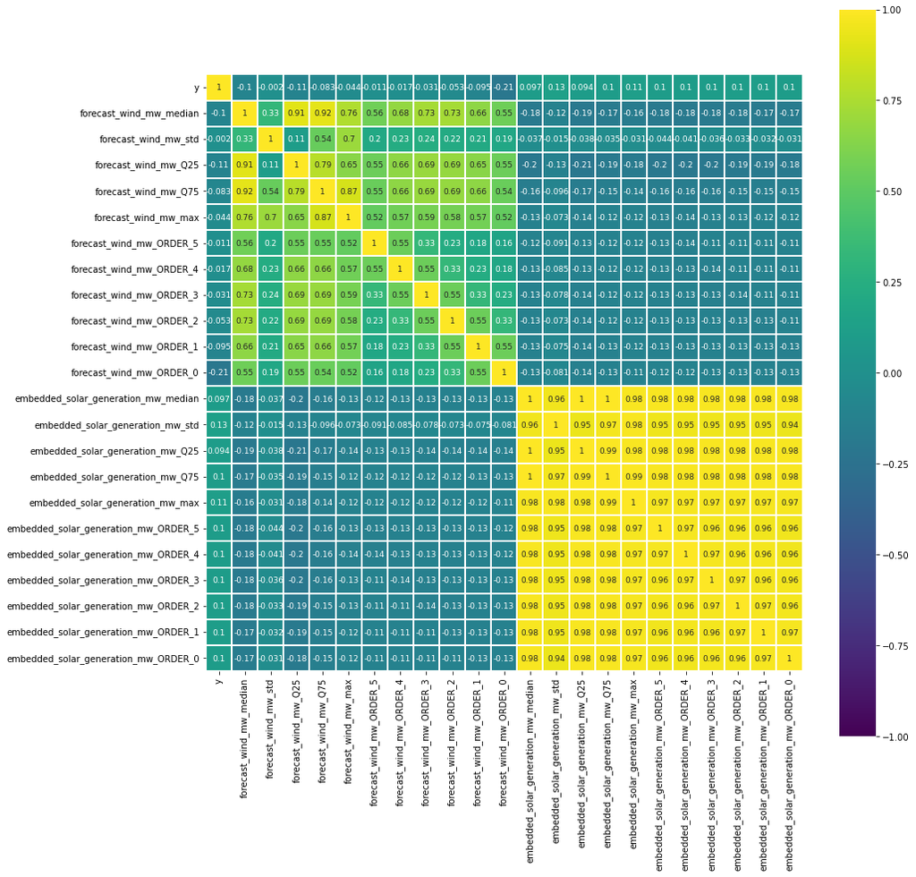

```python
# Correlation measure linear relation strength between two variable. If we have a small value then it does not mean that
# there is no relationship between two variables - there can be non linear relationship
forecast_cols = ['forecast_wind_mw_median', 'forecast_wind_mw_std', 'forecast_wind_mw_Q25', 'forecast_wind_mw_Q75', 'forecast_wind_mw_max', 'forecast_wind_mw_ORDER_5', 'forecast_wind_mw_ORDER_4', 'forecast_wind_mw_ORDER_3', 'forecast_wind_mw_ORDER_2', 'forecast_wind_mw_ORDER_1', 'forecast_wind_mw_ORDER_0']
solar_cols    = ['embedded_solar_generation_mw_median', 'embedded_solar_generation_mw_std', 'embedded_solar_generation_mw_Q25', 'embedded_solar_generation_mw_Q75', 'embedded_solar_generation_mw_max', 'embedded_solar_generation_mw_ORDER_5', 'embedded_solar_generation_mw_ORDER_4', 'embedded_solar_generation_mw_ORDER_3', 'embedded_solar_generation_mw_ORDER_2', 'embedded_solar_generation_mw_ORDER_1', 'embedded_solar_generation_mw_ORDER_0']

corr =  forecast_wind_mw[ ["y"] + forecast_cols + solar_cols].corr(method = "spearman")
plt.figure(figsize = (15,15))
sns.heatmap(corr,
            cmap='viridis', vmax=1.0, vmin=-1.0, linewidths=0.1,
            annot=True, annot_kws={"size": 9}, square=True);
```

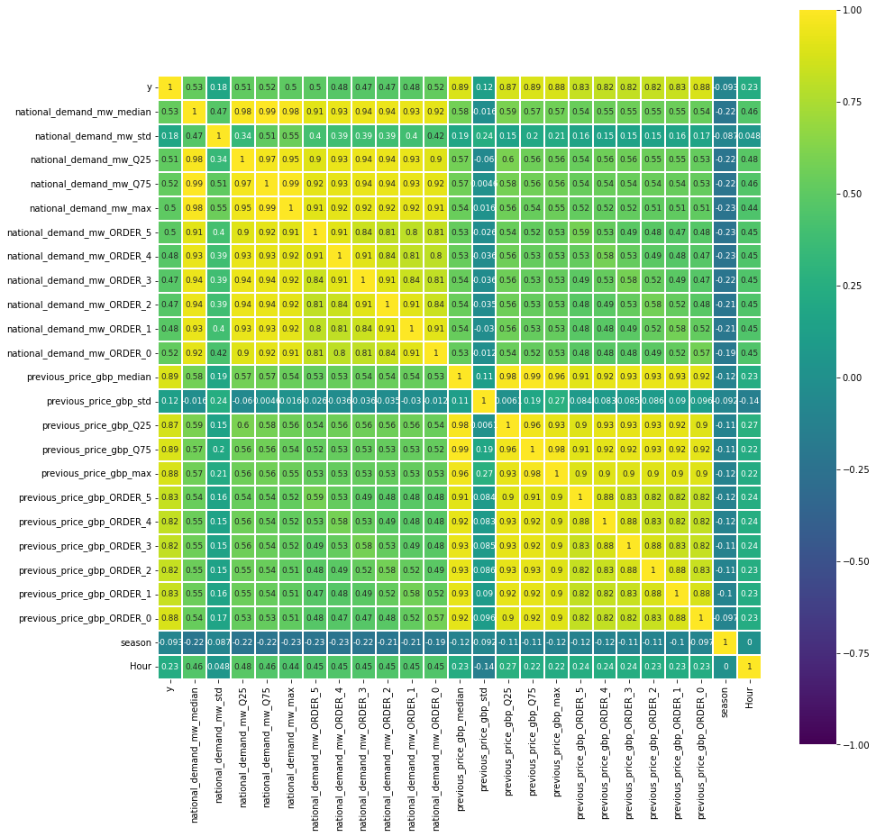

```python
# But there is strong relationship between price and energy demand.
national_demand_cols = ['national_demand_mw_median', 'national_demand_mw_std', 'national_demand_mw_Q25', 'national_demand_mw_Q75', 'national_demand_mw_max', 'national_demand_mw_ORDER_5', 'national_demand_mw_ORDER_4', 'national_demand_mw_ORDER_3', 'national_demand_mw_ORDER_2', 'national_demand_mw_ORDER_1', 'national_demand_mw_ORDER_0']
previous_price_cols  = ['previous_price_gbp_median', 'previous_price_gbp_std', 'previous_price_gbp_Q25', 'previous_price_gbp_Q75', 'previous_price_gbp_max', 'previous_price_gbp_ORDER_5', 'previous_price_gbp_ORDER_4', 'previous_price_gbp_ORDER_3', 'previous_price_gbp_ORDER_2', 'previous_price_gbp_ORDER_1', 'previous_price_gbp_ORDER_0', 'season', 'Hour']

corr =  forecast_wind_mw[ ["y"] + national_demand_cols + previous_price_cols].corr(method = "spearman")
plt.figure(figsize = (15, 15))
sns.heatmap(corr,
            cmap='viridis', vmax=1.0, vmin=-1.0, linewidths=0.1,
            annot=True, annot_kws={"size": 9}, square=True);
```

```python
#creat train, validation and test datasets
nnn = len(forecast_wind_mw)
#
sub_forecast_wind_mw = forecast_wind_mw[train_cols + ["ds", "y"]].copy()
# Count total NaN at each column in a DataFrame
print(" \nCount total NaN at each column in a DataFrame : \n\n",
      sub_forecast_wind_mw.isnull().sum())
#
sub_forecast_wind_mw = sub_forecast_wind_mw.dropna()
print(" \nCount total NaN at each column in a DataFrame : \n\n",
      sub_forecast_wind_mw.isnull().sum())
#
train = sub_forecast_wind_mw.head(int(0.6 * nnn))
val_test = sub_forecast_wind_mw[~sub_forecast_wind_mw["ds"].isin(train["ds"].values)].copy()
val = val_test.head(int(0.5 * len(val_test)))
test = val_test[~val_test["ds"].isin(val["ds"].values)].copy()
#
print("train:")
display(train.head())
display(train.tail())
print("val:")
display(val.head())
display(val.tail())
print("test:")
display(test.head())
display(test.tail())
```

```
Count total NaN at each column in a DataFrame :

 forecast_wind_mw_median                 144
forecast_wind_mw_std                    144
forecast_wind_mw_Q25                    144
forecast_wind_mw_Q75                    144
forecast_wind_mw_max                    144
forecast_wind_mw_ORDER_5                144
forecast_wind_mw_ORDER_4                144
forecast_wind_mw_ORDER_3                144
forecast_wind_mw_ORDER_2                144
forecast_wind_mw_ORDER_1                144
forecast_wind_mw_ORDER_0                144
national_demand_mw_median               120
national_demand_mw_std                  120
national_demand_mw_Q25                  120
national_demand_mw_Q75                  120
national_demand_mw_max                  120
national_demand_mw_ORDER_5              120
national_demand_mw_ORDER_4              120
national_demand_mw_ORDER_3              120
national_demand_mw_ORDER_2              120
national_demand_mw_ORDER_1              120
national_demand_mw_ORDER_0              120
embedded_solar_generation_mw_median     120
embedded_solar_generation_mw_std        120
embedded_solar_generation_mw_Q25        120
embedded_solar_generation_mw_Q75        120
embedded_solar_generation_mw_max        120
embedded_solar_generation_mw_ORDER_5    120
embedded_solar_generation_mw_ORDER_4    120
embedded_solar_generation_mw_ORDER_3    120
embedded_solar_generation_mw_ORDER_2    120
embedded_solar_generation_mw_ORDER_1    120
embedded_solar_generation_mw_ORDER_0    120
previous_price_gbp_median               120
previous_price_gbp_std                  120
previous_price_gbp_Q25                  120
previous_price_gbp_Q75                  120
previous_price_gbp_max                  120
```

[output cut: 49 more lines]

```
previous_price_gbp_Q25                  0
previous_price_gbp_Q75                  0
previous_price_gbp_max                  0
previous_price_gbp_ORDER_5              0
previous_price_gbp_ORDER_4              0
previous_price_gbp_ORDER_3              0
previous_price_gbp_ORDER_2              0
previous_price_gbp_ORDER_1              0
previous_price_gbp_ORDER_0              0
season                                  0
Hour                                    0
ds                                      0
y                                       0
dtype: int64
train:
```

|  | forecast_wind_mw_median | forecast_wind_mw_std | forecast_wind_mw_Q25 | forecast_wind_mw_Q75 | forecast_wind_mw_max | forecast_wind_mw_ORDER_5 | forecast_wind_mw_ORDER_4 | forecast_wind_mw_ORDER_3 | forecast_wind_mw_ORDER_2 | forecast_wind_mw_ORDER_1 | ... | previous_price_gbp_ORDER_5 | previous_price_gbp_ORDER_4 | previous_price_gbp_ORDER_3 | previous_price_gbp_ORDER_2 | previous_price_gbp_ORDER_1 | previous_price_gbp_ORDER_0 | season | Hour | ds | y |
| --- | --- | --- | --- | --- | --- | --- | --- | --- | --- | --- | --- | --- | --- | --- | --- | --- | --- | --- | --- | --- | --- |
| 120 | 1341.5 | 1175.933908 | 1172.00 | 1406.75 | 4282.0 | 4282.0 | 1280.0 | 1403.0 | 719.0 | 1136.0 | ... | 32.71 | 34.01 | 34.00 | 32.00 | 33.07 | 35.20 | 2 | 0 | 2019-07-10 00:00:00 | 32.94 |
| 121 | 1253.0 | 1186.956566 | 1096.25 | 1390.25 | 4275.0 | 4275.0 | 1127.0 | 1379.0 | 737.0 | 1086.0 | ... | 31.96 | 30.47 | 35.34 | 30.30 | 33.04 | 34.00 | 2 | 1 | 2019-07-10 01:00:00 | 32.48 |
| 122 | 1216.0 | 1203.967850 | 1045.00 | 1377.25 | 4306.0 | 4306.0 | 1066.0 | 1366.0 | 770.0 | 1038.0 | ... | 31.93 | 30.01 | 34.00 | 30.00 | 32.97 | 34.00 | 2 | 2 | 2019-07-10 02:00:00 | 32.44 |
| 123 | 1208.0 | 1197.992487 | 1009.50 | 1378.75 | 4294.0 | 4294.0 | 1059.0 | 1357.0 | 823.0 | 993.0 | ... | 31.93 | 27.70 | 31.53 | 29.99 | 32.96 | 33.99 | 2 | 3 | 2019-07-10 03:00:00 | 33.31 |
| 124 | 1209.0 | 1106.445610 | 1015.75 | 1381.25 | 4064.0 | 4064.0 | 1117.0 | 1301.0 | 868.0 | 982.0 | ... | 32.00 | 27.00 | 29.54 | 31.00 | 33.42 | 36.40 | 2 | 4 | 2019-07-10 04:00:00 | 36.96 |

5 rows × 48 columns

|  | forecast_wind_mw_median | forecast_wind_mw_std | forecast_wind_mw_Q25 | forecast_wind_mw_Q75 | forecast_wind_mw_max | forecast_wind_mw_ORDER_5 | forecast_wind_mw_ORDER_4 | forecast_wind_mw_ORDER_3 | forecast_wind_mw_ORDER_2 | forecast_wind_mw_ORDER_1 | ... | previous_price_gbp_ORDER_5 | previous_price_gbp_ORDER_4 | previous_price_gbp_ORDER_3 | previous_price_gbp_ORDER_2 | previous_price_gbp_ORDER_1 | previous_price_gbp_ORDER_0 | season | Hour | ds | y |
| --- | --- | --- | --- | --- | --- | --- | --- | --- | --- | --- | --- | --- | --- | --- | --- | --- | --- | --- | --- | --- | --- |
| 10598 | 3422.5 | 2428.113288 | 1905.00 | 4172.75 | 8519.0 | 8519.0 | 1601.0 | 1133.0 | 4221.0 | 2817.0 | ... | 34.94 | 28.86 | 49.00 | 63.12 | 41.00 | 44.99 | 3 | 14 | 2020-09-17 14:00:00 | 36.36 |
| 10599 | 3563.0 | 2354.105946 | 1884.25 | 4507.50 | 8218.0 | 8218.0 | 1531.0 | 1146.0 | 4616.0 | 2944.0 | ... | 36.95 | 38.00 | 60.04 | 78.14 | 54.00 | 53.09 | 3 | 15 | 2020-09-17 15:00:00 | 42.29 |
| 10600 | 3875.5 | 2223.217613 | 1908.75 | 4837.25 | 7691.0 | 7691.0 | 1458.0 | 1165.0 | 4953.0 | 3261.0 | ... | 47.00 | 47.60 | 73.22 | 123.38 | 61.66 | 63.01 | 3 | 16 | 2020-09-17 16:00:00 | 49.50 |
| 10601 | 4049.5 | 2161.171827 | 2102.75 | 5144.25 | 7462.0 | 7462.0 | 1666.0 | 1152.0 | 5297.0 | 3413.0 | ... | 53.00 | 52.00 | 109.03 | 170.62 | 65.97 | 75.64 | 3 | 17 | 2020-09-17 17:00:00 | 52.44 |
| 10602 | 4245.5 | 2073.551523 | 2349.25 | 5389.50 | 7188.0 | 7188.0 | 1942.0 | 1172.0 | 5546.0 | 3571.0 | ... | 54.39 | 57.99 | 87.20 | 140.00 | 57.20 | 62.00 | 3 | 18 | 2020-09-17 18:00:00 | 48.69 |

5 rows × 48 columns

```
val:
```

|  | forecast_wind_mw_median | forecast_wind_mw_std | forecast_wind_mw_Q25 | forecast_wind_mw_Q75 | forecast_wind_mw_max | forecast_wind_mw_ORDER_5 | forecast_wind_mw_ORDER_4 | forecast_wind_mw_ORDER_3 | forecast_wind_mw_ORDER_2 | forecast_wind_mw_ORDER_1 | ... | previous_price_gbp_ORDER_5 | previous_price_gbp_ORDER_4 | previous_price_gbp_ORDER_3 | previous_price_gbp_ORDER_2 | previous_price_gbp_ORDER_1 | previous_price_gbp_ORDER_0 | season | Hour | ds | y |
| --- | --- | --- | --- | --- | --- | --- | --- | --- | --- | --- | --- | --- | --- | --- | --- | --- | --- | --- | --- | --- | --- |
| 10603 | 4461.0 | 1910.640527 | 2621.75 | 5362.75 | 6809.0 | 6809.0 | 2256.0 | 1259.0 | 5416.0 | 3719.0 | ... | 46.00 | 56.00 | 62.84 | 73.39 | 48.43 | 50.37 | 3 | 19 | 2020-09-17 19:00:00 | 44.77 |
| 10604 | 4609.0 | 1758.430021 | 2955.50 | 5466.75 | 6454.0 | 6454.0 | 2638.0 | 1376.0 | 5310.0 | 3908.0 | ... | 40.83 | 49.92 | 51.17 | 59.94 | 43.95 | 42.93 | 3 | 20 | 2020-09-17 20:00:00 | 39.97 |
| 10605 | 4595.5 | 1629.950451 | 3227.25 | 5621.75 | 6100.0 | 6100.0 | 2962.0 | 1485.0 | 5168.0 | 4023.0 | ... | 36.41 | 37.65 | 42.00 | 46.44 | 39.63 | 37.37 | 3 | 21 | 2020-09-17 21:00:00 | 36.00 |
| 10606 | 4342.5 | 1519.817140 | 3186.00 | 5484.75 | 5784.0 | 5694.0 | 2972.0 | 1538.0 | 4857.0 | 3828.0 | ... | 33.03 | 34.58 | 37.20 | 45.15 | 38.15 | 35.64 | 3 | 22 | 2020-09-17 22:00:00 | 37.29 |
| 10607 | 4654.5 | 1857.272074 | 2624.50 | 5690.75 | 6656.0 | 5847.0 | 2137.0 | 1619.0 | 5222.0 | 4087.0 | ... | 30.74 | 32.67 | 36.51 | 41.43 | 34.01 | 32.75 | 3 | 23 | 2020-09-17 23:00:00 | 34.10 |

5 rows × 48 columns

|  | forecast_wind_mw_median | forecast_wind_mw_std | forecast_wind_mw_Q25 | forecast_wind_mw_Q75 | forecast_wind_mw_max | forecast_wind_mw_ORDER_5 | forecast_wind_mw_ORDER_4 | forecast_wind_mw_ORDER_3 | forecast_wind_mw_ORDER_2 | forecast_wind_mw_ORDER_1 | ... | previous_price_gbp_ORDER_5 | previous_price_gbp_ORDER_4 | previous_price_gbp_ORDER_3 | previous_price_gbp_ORDER_2 | previous_price_gbp_ORDER_1 | previous_price_gbp_ORDER_0 | season | Hour | ds | y |
| --- | --- | --- | --- | --- | --- | --- | --- | --- | --- | --- | --- | --- | --- | --- | --- | --- | --- | --- | --- | --- | --- |
| 14020 | 9217.5 | 1843.435629 | 7727.00 | 10564.00 | 12316.0 | 10243.0 | 8192.0 | 7217.0 | 7572.0 | 12316.0 | ... | 36.00 | 33.1 | 43.0 | 46.0 | 45.00 | 22.00 | 0 | 4 | 2021-02-07 04:00:00 | 32.2 |
| 14021 | 8849.5 | 1784.125128 | 7907.25 | 10328.00 | 12251.0 | 9560.0 | 8139.0 | 7021.0 | 7830.0 | 12251.0 | ... | 44.00 | 44.0 | 47.5 | 50.2 | 43.95 | 20.00 | 0 | 5 | 2021-02-07 05:00:00 | 44.0 |
| 14022 | 8575.0 | 1755.939326 | 8087.75 | 10145.25 | 12168.0 | 8985.0 | 8062.0 | 6847.0 | 8165.0 | 12168.0 | ... | 52.40 | 55.0 | 57.0 | 56.0 | 47.00 | 30.00 | 0 | 6 | 2021-02-07 06:00:00 | 54.4 |
| 14023 | 8591.0 | 1751.706945 | 8152.50 | 10006.75 | 12125.0 | 8580.0 | 8010.0 | 6720.0 | 8602.0 | 12125.0 | ... | 55.25 | 54.2 | 55.8 | 56.0 | 50.00 | 38.83 | 0 | 7 | 2021-02-07 07:00:00 | 57.0 |
| 14024 | 8652.5 | 1759.657227 | 8034.00 | 10048.00 | 12078.0 | 8283.0 | 7951.0 | 6638.0 | 9022.0 | 12078.0 | ... | 58.40 | 58.5 | 59.0 | 59.0 | 52.00 | 56.17 | 0 | 8 | 2021-02-07 08:00:00 | 62.0 |

5 rows × 48 columns

```
test:
```

|  | forecast_wind_mw_median | forecast_wind_mw_std | forecast_wind_mw_Q25 | forecast_wind_mw_Q75 | forecast_wind_mw_max | forecast_wind_mw_ORDER_5 | forecast_wind_mw_ORDER_4 | forecast_wind_mw_ORDER_3 | forecast_wind_mw_ORDER_2 | forecast_wind_mw_ORDER_1 | ... | previous_price_gbp_ORDER_5 | previous_price_gbp_ORDER_4 | previous_price_gbp_ORDER_3 | previous_price_gbp_ORDER_2 | previous_price_gbp_ORDER_1 | previous_price_gbp_ORDER_0 | season | Hour | ds | y |
| --- | --- | --- | --- | --- | --- | --- | --- | --- | --- | --- | --- | --- | --- | --- | --- | --- | --- | --- | --- | --- | --- |
| 14025 | 8761.0 | 1807.746203 | 7993.25 | 10169.25 | 12093.0 | 8075.0 | 7966.0 | 6555.0 | 9447.0 | 12093.0 | ... | 59.0 | 61.0 | 61.0 | 63.0 | 57.0 | 54.0 | 0 | 9 | 2021-02-07 09:00:00 | 59.0 |
| 14026 | 8935.0 | 1962.184278 | 8008.75 | 10444.75 | 12327.0 | 8032.0 | 8001.0 | 6368.0 | 9838.0 | 12327.0 | ... | 57.8 | 61.6 | 61.3 | 62.0 | 61.0 | 61.0 | 0 | 10 | 2021-02-07 10:00:00 | 58.0 |
| 14027 | 9126.5 | 2146.546063 | 7928.00 | 10670.75 | 12523.0 | 8012.0 | 7900.0 | 6064.0 | 10241.0 | 12523.0 | ... | 58.0 | 60.5 | 58.1 | 60.9 | 61.1 | 57.0 | 0 | 11 | 2021-02-07 11:00:00 | 58.4 |
| 14028 | 9321.5 | 2309.958129 | 7800.75 | 10814.50 | 12606.0 | 8028.0 | 7725.0 | 5727.0 | 10615.0 | 12606.0 | ... | 62.0 | 65.0 | 63.0 | 64.6 | 69.0 | 63.1 | 0 | 12 | 2021-02-07 12:00:00 | 62.0 |
| 14029 | 9410.5 | 2418.732272 | 7589.75 | 10902.00 | 12522.0 | 8102.0 | 7419.0 | 5422.0 | 10963.0 | 12522.0 | ... | 59.0 | 62.0 | 60.9 | 60.4 | 64.0 | 63.1 | 0 | 13 | 2021-02-07 13:00:00 | 63.0 |

5 rows × 48 columns

|  | forecast_wind_mw_median | forecast_wind_mw_std | forecast_wind_mw_Q25 | forecast_wind_mw_Q75 | forecast_wind_mw_max | forecast_wind_mw_ORDER_5 | forecast_wind_mw_ORDER_4 | forecast_wind_mw_ORDER_3 | forecast_wind_mw_ORDER_2 | forecast_wind_mw_ORDER_1 | ... | previous_price_gbp_ORDER_5 | previous_price_gbp_ORDER_4 | previous_price_gbp_ORDER_3 | previous_price_gbp_ORDER_2 | previous_price_gbp_ORDER_1 | previous_price_gbp_ORDER_0 | season | Hour | ds | y |
| --- | --- | --- | --- | --- | --- | --- | --- | --- | --- | --- | --- | --- | --- | --- | --- | --- | --- | --- | --- | --- | --- |
| 17443 | 2615.0 | 953.544907 | 1827.00 | 3121.75 | 3704.0 | 3704.0 | 1578.0 | 3277.0 | 907.0 | 2656.0 | ... | 90.7 | 90.0 | 98.00 | 91.70 | 98.0 | 81.8 | 2 | 19 | 2021-06-29 19:00:00 | 87.0 |
| 17444 | 2517.5 | 892.953900 | 1851.75 | 3059.50 | 3494.0 | 3494.0 | 1645.0 | 3225.0 | 881.0 | 2563.0 | ... | 82.9 | 85.0 | 90.00 | 87.00 | 89.2 | 80.0 | 2 | 20 | 2021-06-29 20:00:00 | 85.0 |
| 17445 | 2433.5 | 829.243715 | 1867.00 | 2997.00 | 3254.0 | 3254.0 | 1699.0 | 3164.0 | 863.0 | 2496.0 | ... | 76.0 | 82.0 | 83.55 | 79.00 | 78.5 | 77.0 | 2 | 21 | 2021-06-29 21:00:00 | 80.1 |
| 17446 | 2342.5 | 754.998841 | 1791.25 | 2809.00 | 3046.0 | 2928.0 | 1644.0 | 3046.0 | 858.0 | 2452.0 | ... | 80.0 | 86.0 | 99.00 | 94.60 | 82.6 | 82.3 | 2 | 22 | 2021-06-29 22:00:00 | 82.5 |
| 17447 | 2615.0 | 713.924230 | 1703.75 | 3067.25 | 3185.0 | 3185.0 | 1499.0 | 3119.0 | 1480.0 | 2912.0 | ... | 71.1 | 85.0 | 81.00 | 75.95 | 80.0 | 79.0 | 2 | 23 | 2021-06-29 23:00:00 | 77.5 |

5 rows × 48 columns

```
INFO:prophet:Disabling yearly seasonality. Run prophet with yearly_seasonality=True to override this.
```

```
Validation, MAE:  15.558728266038068 , MRAE:  41.27857714769156
Test, MAE:  24.421400548617772 , MRAE:  13.175619507209179
```

|  | ds | yhat | yhat_lower | yhat_upper | y |
| --- | --- | --- | --- | --- | --- |
| 3412 | 2021-06-29 13:00:00 | 101.506419 | -31.303204 | 234.401811 | 79.5 |
| 3413 | 2021-06-29 14:00:00 | 102.448175 | -29.637906 | 236.319118 | 81.0 |
| 3414 | 2021-06-29 15:00:00 | 106.884255 | -27.913704 | 238.874799 | 90.0 |
| 3415 | 2021-06-29 16:00:00 | 113.134594 | -19.305316 | 246.287038 | 100.9 |
| 3416 | 2021-06-29 17:00:00 | 117.860289 | -16.882169 | 251.621129 | 102.0 |
| 3417 | 2021-06-29 18:00:00 | 118.383772 | -18.495121 | 254.323949 | 97.9 |
| 3418 | 2021-06-29 19:00:00 | 114.637965 | -17.794663 | 245.835136 | 87.0 |
| 3419 | 2021-06-29 20:00:00 | 109.050636 | -26.115949 | 241.947704 | 85.0 |
| 3420 | 2021-06-29 21:00:00 | 104.481043 | -29.840016 | 236.271160 | 80.1 |
| 3421 | 2021-06-29 22:00:00 | 102.053005 | -31.997774 | 235.498361 | 82.5 |
| 3422 | 2021-06-29 23:00:00 | 100.749314 | -35.073067 | 233.627543 | 77.5 |

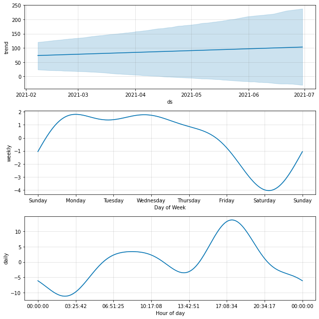

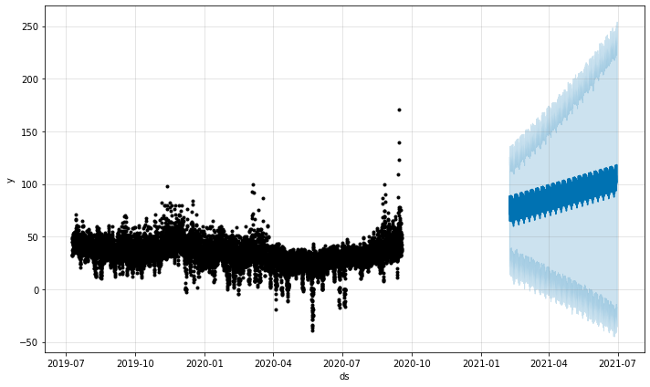

```python
# Face book Prophet using timestaamp and prices only
import warnings
warnings.filterwarnings("ignore", category=FutureWarning)
fp = Prophet(
    #seasonality_mode="multiplicative",
    yearly_seasonality = False,
    weekly_seasonality = False,
    daily_seasonality  = False,
)
#
#m = Prophet(changepoint_prior_scale=0.01).fit(train)
basic_m = Prophet().fit(train)
#
wo_inputs_val_MAE, wo_inputs_val_MRAE = preformance(basic_m, val)
print("Validation, MAE: ", wo_inputs_val_MAE, ", MRAE: ", wo_inputs_val_MRAE)
#
wo_inputs_test_MAE, wo_inputs_test_MRAE = preformance(basic_m, test)
print("Test, MAE: ", wo_inputs_test_MAE, ", MRAE: ", wo_inputs_test_MRAE)
#
forecast = basic_m.predict(test)
forecast = forecast.merge(test[["ds", "y"]], on = "ds")
fig1 = basic_m.plot_components(forecast)
fig2 = basic_m.plot(forecast)
display(forecast[['ds', 'yhat', 'yhat_lower', 'yhat_upper', "y"]].tail(11))
```

```python
# Feedrorwar feature selection
# adding one feature at a time based on val_MRAE
#
# 1) We start we no features, selected_cols = []. Then select the best feature with the smallest val_MRAE.
# If it is smaller than min_MRAE we add it to selected_cols.
# 2) Then again we look at all feature except selected and find the one that when we combine it with the selected_cols
# it gives smallest val_MRAE.
# If the obtained val_MRAE is smaller than min_MRAE we add it to selected_cols.
# We repeat 2) until we can not find the feature that can reduce  min_MRAE.
#
train = train.dropna()
#
results = []
#
selected_cols = [] #"season", "Hour", "forecast_wind_mw_ORDER_4", "forecast_wind_mw_std"]
min_MRAE = wo_inputs_val_MRAE
not_stop = True
#
number_of_inputs = 0
while not_stop:
      candidate_col = None
      for feature in train_cols:
          print(feature)
          if not ( feature in selected_cols ):
             #
             fp = Prophet(yearly_seasonality = True, changepoint_prior_scale=0.01)
             #
             for sub_feature in selected_cols + [feature]:
                 fp.add_regressor(sub_feature, standardize = True)
             #
             m = fp.fit(train)
             #
             val_MAE,  val_MRAE  = preformance(m, val)
             test_MAE, test_MRAE = preformance(m, test)
             #
             elem = {"number_of_select_inputs": len(selected_cols), "feature": feature, "val_MAE": val_MAE, "val_MRAE": val_MRAE, "test_MAE": test_MAE, "test_MRAE": test_MRAE}
             print(elem)
             results.append(elem)
             #
             if min_MRAE > val_MRAE:
                print("!!! feature: ", feature, ", val_MRAE: ", val_MRAE, ", min_MRAE: ", min_MRAE, ", selected_cols: ", selected_cols)
                min_MRAE = val_MRAE
                candidate_col = feature
      #
      if candidate_col is not None:
         selected_cols.append(candidate_col)
      else:
         not_stop = False
#
results_df = pd.DataFrame(results)
results_df = results_df.sort_values(by = "val_MRAE")
```

```
forecast_wind_mw_median
{'number_of_select_inputs': 0, 'feature': 'forecast_wind_mw_median', 'val_MAE': 26.033837564879285, 'val_MRAE': 27.72171502557161, 'test_MAE': 38.296333476340514, 'test_MRAE': 8.135347664132134}
!!! feature:  forecast_wind_mw_median , val_MRAE:  27.72171502557161 , min_MRAE:  41.27857714769156 , selected_cols:  []
forecast_wind_mw_std
{'number_of_select_inputs': 0, 'feature': 'forecast_wind_mw_std', 'val_MAE': 26.51677501426538, 'val_MRAE': 27.318680076064748, 'test_MAE': 39.309043989431615, 'test_MRAE': 8.420814826100667}
!!! feature:  forecast_wind_mw_std , val_MRAE:  27.318680076064748 , min_MRAE:  27.72171502557161 , selected_cols:  []
forecast_wind_mw_Q25
{'number_of_select_inputs': 0, 'feature': 'forecast_wind_mw_Q25', 'val_MAE': 25.841195779474152, 'val_MRAE': 27.95094550465353, 'test_MAE': 37.8717331248425, 'test_MRAE': 7.921863060155783}
forecast_wind_mw_Q75
{'number_of_select_inputs': 0, 'feature': 'forecast_wind_mw_Q75', 'val_MAE': 26.452734004136598, 'val_MRAE': 27.29450093209548, 'test_MAE': 40.363448098065476, 'test_MRAE': 8.941806434535216}
!!! feature:  forecast_wind_mw_Q75 , val_MRAE:  27.29450093209548 , min_MRAE:  27.318680076064748 , selected_cols:  []
forecast_wind_mw_max
{'number_of_select_inputs': 0, 'feature': 'forecast_wind_mw_max', 'val_MAE': 25.765308579159395, 'val_MRAE': 28.113314301708, 'test_MAE': 38.41259372754333, 'test_MRAE': 8.244897576223948}
forecast_wind_mw_ORDER_5
{'number_of_select_inputs': 0, 'feature': 'forecast_wind_mw_ORDER_5', 'val_MAE': 26.372358141530434, 'val_MRAE': 27.481774215753124, 'test_MAE': 37.841772304624165, 'test_MRAE': 7.826938839244646}
forecast_wind_mw_ORDER_4
{'number_of_select_inputs': 0, 'feature': 'forecast_wind_mw_ORDER_4', 'val_MAE': 26.745510561188727, 'val_MRAE': 27.06772019403346, 'test_MAE': 39.55406472811824, 'test_MRAE': 8.419615441669176}
!!! feature:  forecast_wind_mw_ORDER_4 , val_MRAE:  27.06772019403346 , min_MRAE:  27.29450093209548 , selected_cols:  []
forecast_wind_mw_ORDER_3
{'number_of_select_inputs': 0, 'feature': 'forecast_wind_mw_ORDER_3', 'val_MAE': 26.70615906008865, 'val_MRAE': 27.108562471829412, 'test_MAE': 39.125441984804674, 'test_MRAE': 8.193605916276763}
forecast_wind_mw_ORDER_2
{'number_of_select_inputs': 0, 'feature': 'forecast_wind_mw_ORDER_2', 'val_MAE': 26.86648308171312, 'val_MRAE': 26.92116858792905, 'test_MAE': 39.61242305705873, 'test_MRAE': 8.392007036974597}
!!! feature:  forecast_wind_mw_ORDER_2 , val_MRAE:  26.92116858792905 , min_MRAE:  27.06772019403346 , selected_cols:  []
forecast_wind_mw_ORDER_1
{'number_of_select_inputs': 0, 'feature': 'forecast_wind_mw_ORDER_1', 'val_MAE': 26.582565897376345, 'val_MRAE': 27.177913881502743, 'test_MAE': 39.787883524079625, 'test_MRAE': 8.486832642985458}
forecast_wind_mw_ORDER_0
{'number_of_select_inputs': 0, 'feature': 'forecast_wind_mw_ORDER_0', 'val_MAE': 25.879476079788734, 'val_MRAE': 27.618935161290402, 'test_MAE': 40.22896034663532, 'test_MRAE': 9.522597777841353}
national_demand_mw_median
{'number_of_select_inputs': 0, 'feature': 'national_demand_mw_median', 'val_MAE': 23.29877928299849, 'val_MRAE': 30.566934549970856, 'test_MAE': 34.327901395950654, 'test_MRAE': 7.990312927087804}
national_demand_mw_std
{'number_of_select_inputs': 0, 'feature': 'national_demand_mw_std', 'val_MAE': 27.425398018992038, 'val_MRAE': 26.303576142022273, 'test_MAE': 41.08002533999587, 'test_MRAE': 9.041040862081832}
!!! feature:  national_demand_mw_std , val_MRAE:  26.303576142022273 , min_MRAE:  26.92116858792905 , selected_cols:  []
national_demand_mw_Q25
{'number_of_select_inputs': 0, 'feature': 'national_demand_mw_Q25', 'val_MAE': 24.132049392922493, 'val_MRAE': 29.712250353866406, 'test_MAE': 36.82842321642608, 'test_MRAE': 8.03627701006991}
national_demand_mw_Q75
{'number_of_select_inputs': 0, 'feature': 'national_demand_mw_Q75', 'val_MAE': 24.5488597180668, 'val_MRAE': 29.15151135883684, 'test_MAE': 38.60550946223733, 'test_MRAE': 8.745835867889692}
national_demand_mw_max
{'number_of_select_inputs': 0, 'feature': 'national_demand_mw_max', 'val_MAE': 25.218980944364255, 'val_MRAE': 28.470942777226636, 'test_MAE': 39.17680322514586, 'test_MRAE': 8.7706439089268}
national_demand_mw_ORDER_5
{'number_of_select_inputs': 0, 'feature': 'national_demand_mw_ORDER_5', 'val_MAE': 25.164775000832435, 'val_MRAE': 28.6185644843231, 'test_MAE': 38.05202633122427, 'test_MRAE': 8.227931825938098}
```

[output cut: 405 more lines]

```
{'number_of_select_inputs': 4, 'feature': 'previous_price_gbp_max', 'val_MAE': 20.02387426438469, 'val_MRAE': 39.023539632567484, 'test_MAE': 21.804577673442527, 'test_MRAE': 16.898095824880606}
previous_price_gbp_ORDER_5
{'number_of_select_inputs': 4, 'feature': 'previous_price_gbp_ORDER_5', 'val_MAE': 25.086471732244043, 'val_MRAE': 29.333846218827638, 'test_MAE': 36.47685744123211, 'test_MRAE': 8.742798393817633}
previous_price_gbp_ORDER_4
{'number_of_select_inputs': 4, 'feature': 'previous_price_gbp_ORDER_4', 'val_MAE': 25.76207614296982, 'val_MRAE': 28.707613626581537, 'test_MAE': 37.92394907532259, 'test_MRAE': 8.805718211808015}
previous_price_gbp_ORDER_3
{'number_of_select_inputs': 4, 'feature': 'previous_price_gbp_ORDER_3', 'val_MAE': 25.333529392405968, 'val_MRAE': 29.406876526924847, 'test_MAE': 37.17869303381634, 'test_MRAE': 8.916784267001967}
previous_price_gbp_ORDER_2
{'number_of_select_inputs': 4, 'feature': 'previous_price_gbp_ORDER_2', 'val_MAE': 25.575363870011874, 'val_MRAE': 28.77058559883377, 'test_MAE': 38.17245826246147, 'test_MRAE': 8.784331543028655}
previous_price_gbp_ORDER_1
{'number_of_select_inputs': 4, 'feature': 'previous_price_gbp_ORDER_1', 'val_MAE': 24.203520624560262, 'val_MRAE': 30.05092150567485, 'test_MAE': 35.08841452309088, 'test_MRAE': 8.582691588767425}
previous_price_gbp_ORDER_0
{'number_of_select_inputs': 4, 'feature': 'previous_price_gbp_ORDER_0', 'val_MAE': 18.922008652845058, 'val_MRAE': 35.925840812518075, 'test_MAE': 26.130301463460867, 'test_MRAE': 12.815760121203844}
season
Hour
```

```python
selected_cols
```

```
['season', 'Hour', 'forecast_wind_mw_ORDER_4', 'forecast_wind_mw_std']
```

```python
# You can see that embedded_solar_generation_mw_ORDER_2 + using 4 seected features gives the best val_MRAE = 25.94
# that is larger than just using 4 selected features, val_MRAE = 25.81. That is why forward selection algorithm
# select only 4 features.
min_results_df = results_df.groupby("number_of_select_inputs").agg({"val_MRAE": "min"}).reset_index()
selected_feature_results = results_df.merge(min_results_df, on = ["number_of_select_inputs", "val_MRAE"])
selected_feature_results.sort_values(by = "number_of_select_inputs")
```

|  | number_of_select_inputs | feature | val_MAE | val_MRAE | test_MAE | test_MRAE |
| --- | --- | --- | --- | --- | --- | --- |
| 4 | 0 | season | 27.502695 | 26.253962 | 41.858486 | 9.463735 |
| 3 | 1 | Hour | 27.560405 | 26.187100 | 42.174761 | 9.724320 |
| 1 | 2 | forecast_wind_mw_ORDER_4 | 27.924731 | 25.816224 | 43.692922 | 10.680037 |
| 0 | 3 | forecast_wind_mw_std | 27.932384 | 25.814720 | 43.608600 | 10.622442 |
| 2 | 4 | embedded_solar_generation_mw_ORDER_2 | 27.791691 | 25.937152 | 43.511439 | 10.566864 |

```
Performance using forward selection algorithm:
MAE:  43.60859983897657 , MRAE:  10.622441908830819
```

|  | ds | yhat | yhat_lower | yhat_upper | y |
| --- | --- | --- | --- | --- | --- |
| 3412 | 2021-06-29 13:00:00 | 119.096634 | 99.426828 | 140.177657 | 79.5 |
| 3413 | 2021-06-29 14:00:00 | 120.007973 | 100.877337 | 140.538655 | 81.0 |
| 3414 | 2021-06-29 15:00:00 | 124.369101 | 104.538943 | 146.094685 | 90.0 |
| 3415 | 2021-06-29 16:00:00 | 130.498971 | 110.070707 | 150.658726 | 100.9 |
| 3416 | 2021-06-29 17:00:00 | 135.270879 | 115.405421 | 155.803476 | 102.0 |
| 3417 | 2021-06-29 18:00:00 | 135.847002 | 116.419983 | 155.590069 | 97.9 |
| 3418 | 2021-06-29 19:00:00 | 132.121082 | 112.444910 | 152.057321 | 87.0 |
| 3419 | 2021-06-29 20:00:00 | 126.524078 | 108.470599 | 147.197093 | 85.0 |
| 3420 | 2021-06-29 21:00:00 | 121.972309 | 101.664194 | 142.368426 | 80.1 |
| 3421 | 2021-06-29 22:00:00 | 119.651655 | 99.171400 | 139.284681 | 82.5 |
| 3422 | 2021-06-29 23:00:00 | 118.534453 | 98.151265 | 139.143463 | 77.5 |

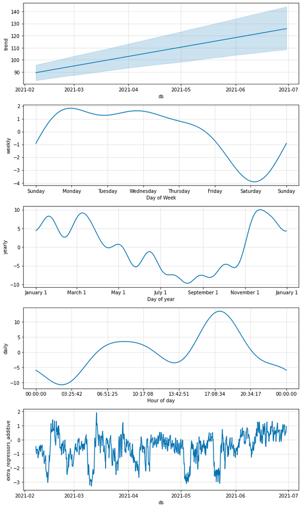

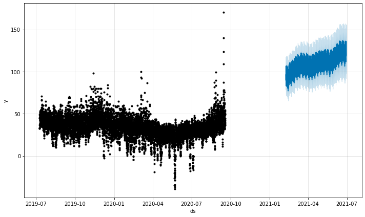

```python
# Performance illustration of model using forward selection
#
SELECTED_COLS_fp = Prophet(yearly_seasonality = True, changepoint_prior_scale=0.01)
#
for feature in selected_cols:
    #
    SELECTED_COLS_fp.add_regressor(feature, standardize = True)
#
SELECTED_COLS_m = SELECTED_COLS_fp.fit(train)
#
SELECTED_COLS_test_MAE, SELECTED_COLS_test_MRAE = preformance(SELECTED_COLS_m, test)
#
print("Performance using forward selection algorithm:")
print("MAE: ", SELECTED_COLS_test_MAE, ", MRAE: ", SELECTED_COLS_test_MRAE)
#
forecast = SELECTED_COLS_m.predict(test)
forecast = forecast.merge(test[["ds", "y"]], on = "ds")
fig1 = SELECTED_COLS_m.plot_components(forecast)
fig2 = SELECTED_COLS_m.plot(forecast)
display(forecast[['ds', 'yhat', 'yhat_lower', 'yhat_upper', "y"]].tail(11))
```

```
{'val_MAE': 15.105249926287119, 'val_MRAE': 41.12138171040958, 'test_MAE': 19.627002923309803, 'test_MRAE': 18.232617455361485}
```

|  | ds | yhat | yhat_lower | yhat_upper | y |
| --- | --- | --- | --- | --- | --- |
| 3412 | 2021-06-29 13:00:00 | 93.823808 | 83.982657 | 103.863863 | 79.5 |
| 3413 | 2021-06-29 14:00:00 | 94.615494 | 84.490805 | 104.987145 | 81.0 |
| 3414 | 2021-06-29 15:00:00 | 102.963689 | 92.898354 | 113.053812 | 90.0 |
| 3415 | 2021-06-29 16:00:00 | 112.172315 | 101.548235 | 122.070397 | 100.9 |
| 3416 | 2021-06-29 17:00:00 | 115.814334 | 105.721510 | 126.371545 | 102.0 |
| 3417 | 2021-06-29 18:00:00 | 114.303635 | 103.990183 | 124.108439 | 97.9 |
| 3418 | 2021-06-29 19:00:00 | 105.879395 | 95.370836 | 116.066312 | 87.0 |
| 3419 | 2021-06-29 20:00:00 | 101.587253 | 91.239276 | 112.048762 | 85.0 |
| 3420 | 2021-06-29 21:00:00 | 97.441332 | 87.672787 | 107.770738 | 80.1 |
| 3421 | 2021-06-29 22:00:00 | 99.947343 | 90.000709 | 109.445594 | 82.5 |
| 3422 | 2021-06-29 23:00:00 | 95.920053 | 86.246150 | 105.871318 | 77.5 |

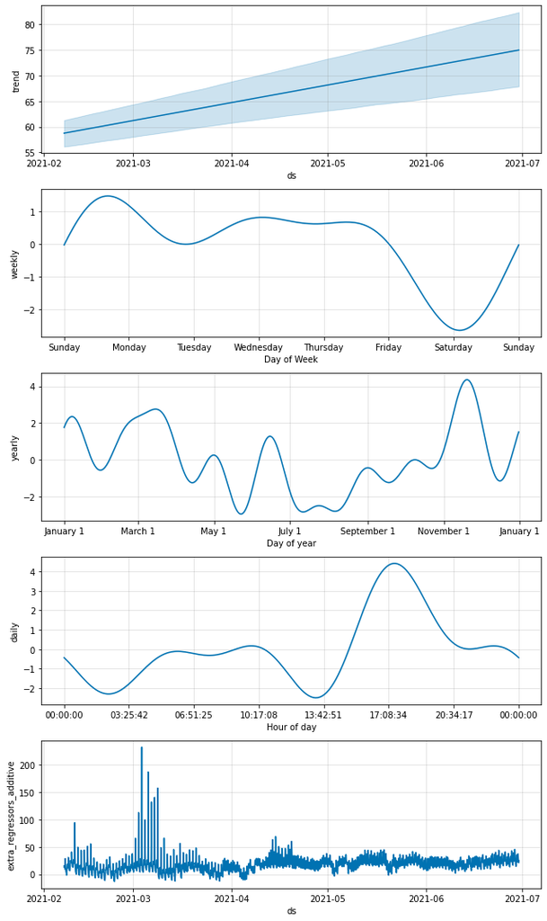

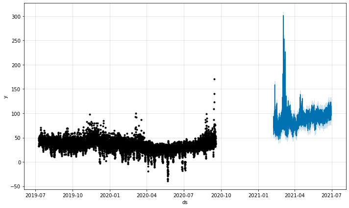

```python
# USE ALL features for Facebook Prophet
ALL_fp = Prophet(yearly_seasonality = True, changepoint_prior_scale=0.01)
#
for feature in train_cols:
    #
    ALL_fp.add_regressor(feature, standardize = True)
#
ALL_m = ALL_fp.fit(train)
#
ALL_val_MAE,  ALL_val_MRAE  = preformance(ALL_m, val)
ALL_test_MAE, ALL_test_MRAE = preformance(ALL_m, test)
#
elem = {"val_MAE": ALL_val_MAE, "val_MRAE": ALL_val_MRAE, "test_MAE": ALL_test_MAE, "test_MRAE": ALL_test_MRAE}
print(elem)
forecast = ALL_m.predict(test)
forecast = forecast.merge(test[["ds", "y"]], on = "ds")
fig1 = ALL_m.plot_components(forecast)
fig2 = ALL_m.plot(forecast)
display(forecast[['ds', 'yhat', 'yhat_lower', 'yhat_upper', "y"]].tail(11))
```

```python
# if "GP_prediction.csv" exists then we just load results of Gaussian Processes forecast
# otherwise we compute forecast using Gaussian Processes
# Gaussian Processes in sliding windows
# we use the following features:
# ['previous_price_gbp_ORDER_5', 'previous_price_gbp_ORDER_4',
#  'previous_price_gbp_ORDER_3', 'previous_price_gbp_ORDER_2',
#  'previous_price_gbp_ORDER_1', 'previous_price_gbp_ORDER_0',
#  'season', 'Hour']
#
# We have not use any feture selection algorithm here.
#
#
path_to_file = "GP_prediction.csv"
#
if os.path.exists(path_to_file):
   print("Read results of GP prediction")
   final = pd.read_csv(path_to_file, index_col = 0)
else:
  #
  kernel = 1.0 * RBF(length_scale=1e1, length_scale_bounds=(1e-2, 1e3)) + WhiteKernel(
                     noise_level=1, noise_level_bounds=(1e-5, 2e1) )
  #
  gpr = GaussianProcessRegressor(kernel=kernel, alpha=0.0)
  #
  data = sub_forecast_wind_mw.copy()
  #
  window_size = 11
  Hours = data["Hour"].unique()
  #
  final_df =pd.DataFrame()
  #
  data["recommended price"] = np.nan
  data["std"] = np.nan
  #
  for Hour in Hours:
    print("Hour: ", Hour)
    hour_data = data[data["Hour"] == Hour].copy()
    #
    hour_data.sort_values(by = "ds", inplace = True)
    #
    hour_data.index = list(range(len(hour_data)))
    index = list(range(len(hour_data)))
    #
    start = time()
    #
    for i in range(window_size, len(hour_data)):
        # get previous 10 month prices
        X_train = hour_data.loc[index[i-window_size: i], :].copy()
        #
        if 1 :
           GP_train_cols = ['previous_price_gbp_ORDER_5', 'previous_price_gbp_ORDER_4',
                            'previous_price_gbp_ORDER_3', 'previous_price_gbp_ORDER_2',
                            'previous_price_gbp_ORDER_1', 'previous_price_gbp_ORDER_0']#,
                            #'season', 'Hour']#, 'forecast_wind_mw_ORDER_4', 'forecast_wind_mw_std']
        else:
           GP_train_cols = train_cols.copy()
        #
        y_train = X_train["y"].values.copy()
        X_train = X_train[GP_train_cols].values.copy()
        #
        gpr.fit(X_train, y_train)
        #
        X_test = hour_data.loc[index[i], :].copy()
        X_test = X_test[GP_train_cols].values.copy()
        #
        y_mean, y_std = gpr.predict([X_test], return_std=True)
        #print(y_mean)
        #
        hour_data.loc[index[i], "recommended price"] = y_mean[0]
        hour_data.loc[index[i], "std"              ] = y_std[0]
    #
    final_df = final_df.append(hour_data)
    #
    end = time()
    #
    print("Computation of GP prediction for Hour ", Hour, " took ", np.round(end - start, 2), " seconds")
    print("Save results for Hour ", Hour, " forecast using GP", ", i: ", i)
    #
    final_df.to_csv(path_to_file)
#
print("OK")
```

```
Hour:  0
Computation of GP prediction for Hour  0  took  19.63  seconds
Save results for Hour  0  forecast using GP , i:  721
Hour:  1
Computation of GP prediction for Hour  1  took  19.07  seconds
Save results for Hour  1  forecast using GP , i:  721
Hour:  2
Computation of GP prediction for Hour  2  took  20.45  seconds
Save results for Hour  2  forecast using GP , i:  721
Hour:  3
Computation of GP prediction for Hour  3  took  19.2  seconds
Save results for Hour  3  forecast using GP , i:  721
Hour:  4
Computation of GP prediction for Hour  4  took  21.11  seconds
Save results for Hour  4  forecast using GP , i:  721
Hour:  5
Computation of GP prediction for Hour  5  took  20.39  seconds
Save results for Hour  5  forecast using GP , i:  721
Hour:  6
Computation of GP prediction for Hour  6  took  20.16  seconds
Save results for Hour  6  forecast using GP , i:  721
Hour:  7
Computation of GP prediction for Hour  7  took  20.01  seconds
Save results for Hour  7  forecast using GP , i:  721
Hour:  8
Computation of GP prediction for Hour  8  took  18.45  seconds
Save results for Hour  8  forecast using GP , i:  721
Hour:  9
Computation of GP prediction for Hour  9  took  17.55  seconds
Save results for Hour  9  forecast using GP , i:  721
Hour:  10
Computation of GP prediction for Hour  10  took  19.48  seconds
Save results for Hour  10  forecast using GP , i:  721
Hour:  11
Computation of GP prediction for Hour  11  took  19.99  seconds
Save results for Hour  11  forecast using GP , i:  721
Hour:  12
Computation of GP prediction for Hour  12  took  19.29  seconds
Save results for Hour  12  forecast using GP , i:  721
Hour:  13
```

[output cut: 18 more lines]

```
Computation of GP prediction for Hour  19  took  18.61  seconds
Save results for Hour  19  forecast using GP , i:  721
Hour:  20
Computation of GP prediction for Hour  20  took  19.11  seconds
Save results for Hour  20  forecast using GP , i:  721
Hour:  21
Computation of GP prediction for Hour  21  took  21.46  seconds
Save results for Hour  21  forecast using GP , i:  721
Hour:  22
Computation of GP prediction for Hour  22  took  23.3  seconds
Save results for Hour  22  forecast using GP , i:  721
Hour:  23
Computation of GP prediction for Hour  23  took  21.65  seconds
Save results for Hour  23  forecast using GP , i:  721
OK
```

```python
final_df = final_df[train_cols + ['ds', 'y', "recommended price", "std"]]
final_df
```

|  | forecast_wind_mw_median | forecast_wind_mw_std | forecast_wind_mw_Q25 | forecast_wind_mw_Q75 | forecast_wind_mw_max | forecast_wind_mw_ORDER_5 | forecast_wind_mw_ORDER_4 | forecast_wind_mw_ORDER_3 | forecast_wind_mw_ORDER_2 | forecast_wind_mw_ORDER_1 | ... | previous_price_gbp_ORDER_3 | previous_price_gbp_ORDER_2 | previous_price_gbp_ORDER_1 | previous_price_gbp_ORDER_0 | season | Hour | ds | y | recommended price | std |
| --- | --- | --- | --- | --- | --- | --- | --- | --- | --- | --- | --- | --- | --- | --- | --- | --- | --- | --- | --- | --- | --- |
| 0 | 1341.5 | 1175.933908 | 1172.00 | 1406.75 | 4282.0 | 4282.0 | 1280.0 | 1403.0 | 719.0 | 1136.0 | ... | 34.00 | 32.00 | 33.07 | 35.20 | 2 | 0 | 2019-07-10 00:00:00 | 32.94 | NaN | NaN |
| 1 | 1341.5 | 434.415092 | 1172.00 | 1406.75 | 2173.0 | 1280.0 | 1403.0 | 719.0 | 1136.0 | 1408.0 | ... | 32.00 | 33.07 | 35.20 | 32.94 | 2 | 0 | 2019-07-11 00:00:00 | 38.41 | NaN | NaN |
| 2 | 1405.5 | 846.416564 | 1202.75 | 1981.75 | 3319.0 | 1403.0 | 719.0 | 1136.0 | 1408.0 | 2173.0 | ... | 33.07 | 35.20 | 32.94 | 38.41 | 2 | 0 | 2019-07-12 00:00:00 | 38.39 | NaN | NaN |
| 3 | 1627.0 | 837.170516 | 1204.00 | 2091.25 | 3319.0 | 719.0 | 1136.0 | 1408.0 | 2173.0 | 3319.0 | ... | 35.20 | 32.94 | 38.41 | 38.39 | 2 | 0 | 2019-07-13 00:00:00 | 41.94 | NaN | NaN |
| 4 | 1627.0 | 735.722642 | 1341.25 | 2091.25 | 3319.0 | 1136.0 | 1408.0 | 2173.0 | 3319.0 | 1846.0 | ... | 32.94 | 38.41 | 38.39 | 41.94 | 2 | 0 | 2019-07-14 00:00:00 | 38.39 | NaN | NaN |
| ... | ... | ... | ... | ... | ... | ... | ... | ... | ... | ... | ... | ... | ... | ... | ... | ... | ... | ... | ... | ... | ... |
| 717 | 2668.0 | 1570.152187 | 1662.00 | 4288.25 | 5127.0 | 5127.0 | 2151.0 | 864.0 | 4656.0 | 3185.0 | ... | 75.00 | 75.00 | 71.10 | 85.00 | 2 | 23 | 2021-06-25 23:00:00 | 81.00 | 73.848230 | 4.677348 |
| 718 | 2635.0 | 1242.549395 | 1662.00 | 3168.50 | 4656.0 | 2151.0 | 864.0 | 4656.0 | 3185.0 | 1499.0 | ... | 75.00 | 71.10 | 85.00 | 81.00 | 2 | 23 | 2021-06-26 23:00:00 | 75.95 | 75.174785 | 4.730877 |
| 719 | 2309.0 | 1304.680729 | 1484.75 | 3168.50 | 4656.0 | 864.0 | 4656.0 | 3185.0 | 1499.0 | 3119.0 | ... | 71.10 | 85.00 | 81.00 | 75.95 | 2 | 23 | 2021-06-27 23:00:00 | 80.00 | 75.492181 | 4.693091 |
| 720 | 3015.5 | 1091.011266 | 1852.25 | 3168.50 | 4656.0 | 4656.0 | 3185.0 | 1499.0 | 3119.0 | 1480.0 | ... | 85.00 | 81.00 | 75.95 | 80.00 | 2 | 23 | 2021-06-28 23:00:00 | 79.00 | 76.577037 | 4.402966 |
| 721 | 2615.0 | 713.924230 | 1703.75 | 3067.25 | 3185.0 | 3185.0 | 1499.0 | 3119.0 | 1480.0 | 2912.0 | ... | 81.00 | 75.95 | 80.00 | 79.00 | 2 | 23 | 2021-06-29 23:00:00 | 77.50 | 76.897024 | 4.359279 |

17328 rows × 50 columns

```python
wo_na_final_df = final_df.dropna()
#
wo_na_final_df.sort_values(by = "ds", inplace = True)
#
wo_na_final_df["MAE" ] = wo_na_final_df.apply(lambda x: np.abs(x["y"] - x["recommended price"]), axis = 1)
wo_na_final_df["MRAE"] = wo_na_final_df.apply(lambda x: np.abs((x["y"] - x["recommended price"]) * 100 / x["y"]) if x["y"] != 0.0 else np.abs(x["y"] - x["recommended price"]), axis = 1)
#
val_wo_na_final_df  = wo_na_final_df.merge( val[["ds"]], on = "ds")
test_wo_na_final_df = wo_na_final_df.merge(test[["ds"]], on = "ds")
print("Validation, MAE: " , val_wo_na_final_df[ "MAE"].mean(), ", MRAE: ", val_wo_na_final_df[ "MRAE"].mean())
print("Test,       MAE: " , test_wo_na_final_df["MAE"].mean(), ", MRAE: ", test_wo_na_final_df["MRAE"].mean())
```

```
Validation, MAE:  18.858925309401585 , MRAE:  116.55764304487771
Test,       MAE:  13.679647775385533 , MRAE:  22.91250185541275
```

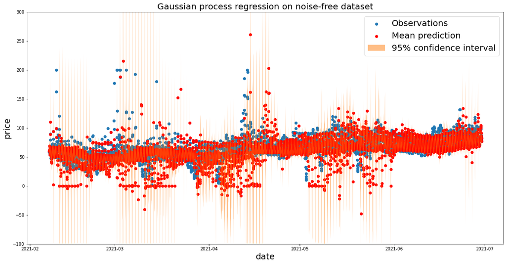

```python
plt.rcParams["figure.figsize"] = (20,10)
X = test_wo_na_final_df["ds"].values.copy()
y = test_wo_na_final_df["y"].values.copy()
#
mean_prediction = test_wo_na_final_df["recommended price"].values.copy()
std_prediction  = test_wo_na_final_df["std"].values.copy()

y[y > 200] = 200
#plt.plot(X, y, label= "Observations", linestyle="dotted", color='C0')
plt.scatter(X, y, label="Observations")
plt.scatter(X, mean_prediction, label="Mean prediction", color = "r")
#plt.plot(X, mean_prediction, label="Mean prediction", color = "r")
plt.fill_between(
    X.ravel(),
    mean_prediction - 1.96 * std_prediction,
    mean_prediction + 1.96 * std_prediction,
    alpha=0.5,
    label=r"95% confidence interval",
)
plt.legend()
plt.ylim([-100, 300])
plt.legend(fontsize=20)
plt.xlabel("date", fontsize=20)
plt.ylabel("price", fontsize=20)
_ = plt.title("Gaussian process regression on noise-free dataset", fontsize = 20)
```

```python
#
val_wo_na_final_df.to_csv("GP_val_wo_na_final_df.csv")
val_wo_na_final_df.groupby("Hour").agg({"MAE": "mean", "MRAE": "mean"}).reset_index()
```

|  | Hour | MAE | MRAE |
| --- | --- | --- | --- |
| 0 | 0 | 12.442041 | 339.809421 |
| 1 | 1 | 12.663141 | 480.792507 |
| 2 | 2 | 11.423048 | 501.028140 |
| 3 | 3 | 11.191480 | 80.989733 |
| 4 | 4 | 11.980900 | 239.166093 |
| 5 | 5 | 12.367008 | 610.952219 |
| 6 | 6 | 14.329066 | 49.217744 |
| 7 | 7 | 13.131210 | 37.804175 |
| 8 | 8 | 14.424659 | 28.213155 |
| 9 | 9 | 16.599124 | 27.159708 |
| 10 | 10 | 15.058603 | 23.497624 |
| 11 | 11 | 15.168621 | 22.751192 |
| 12 | 12 | 16.401588 | 22.835774 |
| 13 | 13 | 12.822371 | 18.356527 |
| 14 | 14 | 12.453352 | 20.126691 |
| 15 | 15 | 10.979319 | 19.031365 |
| 16 | 16 | 46.641853 | 45.870408 |
| 17 | 17 | 100.984227 | 64.690520 |
| 18 | 18 | 50.393145 | 48.132011 |
| 19 | 19 | 12.947676 | 18.090658 |
| 20 | 20 | 4.339734 | 8.185578 |
| 21 | 21 | 5.046266 | 12.195851 |
| 22 | 22 | 6.618763 | 18.900115 |
| 23 | 23 | 12.968640 | 53.620318 |

```python
test_wo_na_final_df.to_csv("GP_test_wo_na_final_df.csv")
test_wo_na_final_df.groupby("Hour").agg({"MAE": "mean", "MRAE": "mean"}).reset_index()
```

|  | Hour | MAE | MRAE |
| --- | --- | --- | --- |
| 0 | 0 | 13.830800 | 29.104980 |
| 1 | 1 | 14.343886 | 33.553160 |
| 2 | 2 | 15.174900 | 39.037609 |
| 3 | 3 | 16.150125 | 43.769462 |
| 4 | 4 | 13.105855 | 34.147988 |
| 5 | 5 | 14.756555 | 29.250654 |
| 6 | 6 | 17.424252 | 30.049006 |
| 7 | 7 | 16.471812 | 26.065332 |
| 8 | 8 | 11.316870 | 16.825274 |
| 9 | 9 | 9.540715 | 15.249746 |
| 10 | 10 | 9.020645 | 13.607012 |
| 11 | 11 | 10.083258 | 15.039969 |
| 12 | 12 | 9.572743 | 17.180898 |
| 13 | 13 | 8.526698 | 17.419857 |
| 14 | 14 | 8.927159 | 18.101845 |
| 15 | 15 | 8.551707 | 13.885046 |
| 16 | 16 | 11.358209 | 14.754240 |
| 17 | 17 | 28.926405 | 29.956835 |
| 18 | 18 | 41.609121 | 35.772942 |
| 19 | 19 | 17.187011 | 20.130447 |
| 20 | 20 | 7.678297 | 10.963685 |
| 21 | 21 | 6.084854 | 10.185792 |
| 22 | 22 | 8.263290 | 14.590647 |
| 23 | 23 | 10.472522 | 21.786226 |

```python
start = time()
kernel = 1.0 * RBF(length_scale=1e1, length_scale_bounds=(1e-2, 1e3)) + WhiteKernel(
                   noise_level=1, noise_level_bounds=(1e-5, 2e1) )
#
gpr = GaussianProcessRegressor(kernel=kernel, alpha=0.0)
#
GP_train_cols = ['previous_price_gbp_ORDER_5', 'previous_price_gbp_ORDER_4',
                 'previous_price_gbp_ORDER_3', 'previous_price_gbp_ORDER_2',
                 'previous_price_gbp_ORDER_1', 'previous_price_gbp_ORDER_0',
                 'season', 'Hour']
#
sub_train = train.sample(n = 1000, replace = False, random_state = 1)
X_train = sub_train[GP_train_cols].values.copy()
y_train = sub_train["y"].values.copy()
#
gpr.fit(X_train, y_train)
#
X_test = test[GP_train_cols].values.copy()

y_mean, y_std = gpr.predict(X_test, return_std=True)
#
end = time()
print("Computation time  is ", end - start)
```

```
Computation time  is  5.7117531299591064
```

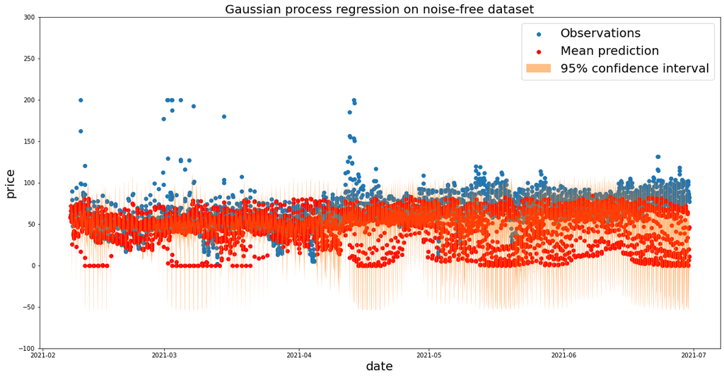

```python
plt.rcParams["figure.figsize"] = (20, 10)
X = test["ds"].values.copy()
y = test["y"].values.copy()
#
mean_prediction = y_mean.copy()
std_prediction  = y_std.copy()

y[y > 200] = 200
#
plt.scatter(X, y, label="Observations")
plt.scatter(X, mean_prediction, label="Mean prediction", color = "r")
#plt.plot(X, mean_prediction, label="Mean prediction", color = "r")
plt.fill_between(
    X.ravel(),
    mean_prediction - 1.96 * std_prediction,
    mean_prediction + 1.96 * std_prediction,
    alpha=0.5,
    label=r"95% confidence interval",
)
plt.legend()
plt.ylim([-100, 300])
plt.legend(fontsize=20)
plt.xlabel("date", fontsize=20)
plt.ylabel("price", fontsize=20)
_ = plt.title("Gaussian process regression on noise-free dataset", fontsize = 20)
```

```python
y = test["y"].values
MAE = np.mean( np.abs(y_mean - y) )
MRAE = np.mean( np.abs( (y_mean - y) * 100/ y) )
print("MAE: ", MAE, "MRAE: ", MRAE)
```

```
MAE:  24.326277079132236 MRAE:  34.15153759822027
```

```python
len(train)
```

```
10483
```